# Rating VQ and Nasalisation Pharyngeals

Jalal Al-Tamimi

Newcastle University

09 June 2018

# 1 Introduction

This analysis accompanies the article “Khattab, G., Al-Tamimi, J., and Al-Siraih, W., (2018). Nasalisation in the production of Iraqi Arabic pharyngeals. Phonetica. DOI: https://10.1159/000487806”. Below is an analysis of the perceptual experiment that was run to evaluate raters impressions of voice quality changes and/or nasalisation that was present within pharyngeals in Iraqi Arabic.

# 2 Material

Data were recorded from nine Iraqi Arabic speakers producing a list of items containing the two pharyngeal consonants /ħ ʕ/ and either an oral context (i.e., oral consonant), a nasal context (i.e., nasal consonant), or only two pharyngeals (/ʕ-ʕ/). The “control” contexts were oral-oral, oral-nasal, nasal-oral, nasal-nasal, and Isolation (which was all vowels in the items produced in isolation). The items were in a CVC environment.

Our aim in this analysis was to evaluate the impression of harsh/tense voice quality and/or nasalisation in the pharyngeal contexts, as compared with all other contexts specified above was perceptually salient or not. For this, six phonetically trained raters (including the first two authors) rated these items using Praat’s MFC experiment. The data used here were a subset of the data (around 20% of the full dataset). The first author rated all items from the full dataset and the results obtained from the full set and the subset are comparable. We ran this as a rating experiment, with three levels rating for Voice Quality (experiment 1) and five levels rating for Nasalisation (experiment 2). For more details, see the article.

# 3 Statistical analyses

The results of the rating experiment were analysed using an Inter-Rater Reliability test and then using a Cumulative Logit Mixed Models. The aim of these two analsyes is to shed light into how pharyngeals, when in a nasal context show clear patterns of a nasal context.

## 3.1 Inter-Rater Reliability

We started by evaluating Inter-Rater Reliability (IRR) using Intra-Class Correlations (ICC) on each of the Voice Quality and the Nasalisation rating experiments. We were interested in both consistency and agreement between the six rater. Results in the article are reported only for the agreement. Here we present and discuss both.

### 3.1.1 Loading required packages

```r
requiredPackages = c('dplyr','irr','reshape2')
for(p in requiredPackages){
  if(!require(p,character.only = TRUE)) install.packages(p)
  library(p,character.only = TRUE)
}
```

### 3.1.2 Reading in data

We read in the data and check the structure

```r
pharyngealsVQIRR <- read.csv("pharyngealsVQIRR.csv")
pharyngealsNasIRR <- read.csv("pharyngealsNasIRR.csv")
str(pharyngealsVQIRR)
```

```
'data.frame':   2430 obs. of  4 variables:
 $ subjectNew  : Factor w/ 9 levels "p01","p02","p03",..: 4 4 4 4 4 4 4 4 4 4 ...
 $ wordTarget  : Factor w/ 45 levels "3aaf-w","3aam-w",..: 38 37 24 23 41 40 8 7 27 19 ...
 $ raterNumber : Factor w/ 6 levels "R01","R02","R03",..: 2 2 2 2 2 2 2 2 2 2 ...
 $ responseNumb: int  3 2 3 3 3 2 3 3 3 3 ...
```

```r
str(pharyngealsNasIRR)
```

```
'data.frame':   2430 obs. of  4 variables:
 $ subjectNew  : Factor w/ 9 levels "p01","p02","p03",..: 4 4 4 4 4 4 4 4 4 4 ...
 $ wordTarget  : Factor w/ 45 levels "3aaf-w","3aam-w",..: 38 37 24 23 41 40 8 7 27 19 ...
 $ raterNumber : Factor w/ 6 levels "R01","R02","R03",..: 2 2 2 2 2 2 2 2 2 2 ...
 $ responseNumb: int  4 4 4 3 3 4 2 3 2 4 ...
```

### 3.1.3 Melting and casting the data

We change a few points in the data-frame. We transform the responses into numbers. We then melt and decast the data to have it in a wide format. The new structure has 9 rows (representing data from each producing subject) and 270 columns with the ratings from each word and rater ID.

```r
## change response into a number
pharyngealsVQIRR$responseNumb <- as.numeric(pharyngealsVQIRR$responseNumb)
pharyngealsNasIRR$responseNumb <- as.numeric(pharyngealsNasIRR$responseNumb)
## casting and melting the data frame, VQ first
pharyngealsVQIRRCast <- dcast(melt(pharyngealsVQIRR, id.vars=c("subjectNew", "wordTarget","raterNumber")), subjectNew~wordTarget+raterNumber)
## casting and melting the data frame, nasalisation second
pharyngealsNasIRRCast <- dcast(melt(pharyngealsNasIRR, id.vars=c("subjectNew", "wordTarget","raterNumber")), subjectNew~wordTarget+raterNumber)
str(pharyngealsVQIRRCast)
```

```
'data.frame':   9 obs. of  271 variables:
 $ subjectNew : Factor w/ 9 levels "p01","p02","p03",..: 1 2 3 4 5 6 7 8 9
 $ 3aaf-w_R01 : num  3 3 3 2 3 3 2 2 3
 $ 3aaf-w_R02 : num  3 3 3 3 3 3 3 3 3
 $ 3aaf-w_R03 : num  2 2 2 2 3 2 2 2 3
 $ 3aaf-w_R04 : num  3 2 3 1 3 1 3 3 3
 $ 3aaf-w_R05 : num  2 3 3 3 3 3 3 3 3
 $ 3aaf-w_R06 : num  3 3 3 3 3 3 3 2 3
 $ 3aam-w_R01 : num  3 2 3 2 3 3 2 3 2
 $ 3aam-w_R02 : num  3 3 3 3 3 3 3 3 3
 $ 3aam-w_R03 : num  2 2 2 2 3 2 2 2 2
 $ 3aam-w_R04 : num  3 2 3 2 3 1 2 3 2
 $ 3aam-w_R05 : num  2 3 3 3 3 2 3 3 2
 $ 3aam-w_R06 : num  2 2 2 2 2 2 2 3 2
 $ 3eeb-v_R01 : num  2 2 2 1 2 2 2 2 2
```

[output cut: 86 more lines]

### 3.1.4 Intra-Class Correlations (ICC)

We used ICCs to compute inter-rater reliability. For details see the article. We ran two types of tests. We wanted to check how consistent the raters were in their choices and also how they agree between each other. The agreements were reported in the article. We start by reporting the overall consistency and agreement levels for each of the VQ and Nasalisation experiments and then on the consistency and agreement on each word, i.e., an Item-based analysis.

#### 3.1.4.1 Voice Quality (VQ)

We start with the VQ experiment.

##### 3.1.4.1.1 Consistency

Below are the model specifications for the consistency.

```r
VQICCRatingConsWordAver <- icc(pharyngealsVQIRRCast[2:271],model="twoway",type="consistency",unit="average")
VQICCRatingConsWordAver3aafw <- icc(pharyngealsVQIRRCast[2:7],model="twoway",type="consistency",unit="average")
VQICCRatingConsWordAver3aamw <- icc(pharyngealsVQIRRCast[8:13],model="twoway",type="consistency",unit="average")
VQICCRatingConsWordAver3eebv <- icc(pharyngealsVQIRRCast[14:19],model="twoway",type="consistency",unit="average")
VQICCRatingConsWordAver3eebw <- icc(pharyngealsVQIRRCast[20:25],model="twoway",type="consistency",unit="average")
VQICCRatingConsWordAver3eenw <- icc(pharyngealsVQIRRCast[26:31],model="twoway",type="consistency",unit="average")
VQICCRatingConsWordAver3iishw <- icc(pharyngealsVQIRRCast[32:37],model="twoway",type="consistency",unit="average")
VQICCRatingConsWordAver3oo3v <- icc(pharyngealsVQIRRCast[38:43],model="twoway",type="consistency",unit="average")
VQICCRatingConsWordAver3oo3w <- icc(pharyngealsVQIRRCast[44:49],model="twoway",type="consistency",unit="average")
VQICCRatingConsWordAver3oonw <- icc(pharyngealsVQIRRCast[50:55],model="twoway",type="consistency",unit="average")
VQICCRatingConsWordAver7aadw <- icc(pharyngealsVQIRRCast[56:61],model="twoway",type="consistency",unit="average")
VQICCRatingConsWordAver7eefv <- icc(pharyngealsVQIRRCast[62:67],model="twoway",type="consistency",unit="average")
VQICCRatingConsWordAver7eefw <- icc(pharyngealsVQIRRCast[68:73],model="twoway",type="consistency",unit="average")
VQICCRatingConsWordAver7enw <- icc(pharyngealsVQIRRCast[74:79],model="twoway",type="consistency",unit="average")
VQICCRatingConsWordAver7ookw <- icc(pharyngealsVQIRRCast[80:85],model="twoway",type="consistency",unit="average")
VQICCRatingConsWordAver7oomw <- icc(pharyngealsVQIRRCast[86:91],model="twoway",type="consistency",unit="average")
VQICCRatingConsWordAverbaa3w <- icc(pharyngealsVQIRRCast[92:97],model="twoway",type="consistency",unit="average")
VQICCRatingConsWordAverbeetw <- icc(pharyngealsVQIRRCast[98:103],model="twoway",type="consistency",unit="average")
VQICCRatingConsWordAverbii3v <- icc(pharyngealsVQIRRCast[104:109],model="twoway",type="consistency",unit="average")
VQICCRatingConsWordAverbii3w <- icc(pharyngealsVQIRRCast[110:115],model="twoway",type="consistency",unit="average")
VQICCRatingConsWordAverbooshw <- icc(pharyngealsVQIRRCast[116:121],model="twoway",type="consistency",unit="average")
VQICCRatingConsWordAverdaasw <- icc(pharyngealsVQIRRCast[122:127],model="twoway",type="consistency",unit="average")
VQICCRatingConsWordAverdiinw <- icc(pharyngealsVQIRRCast[128:133],model="twoway",type="consistency",unit="average")
VQICCRatingConsWordAverdjuu3v <- icc(pharyngealsVQIRRCast[134:139],model="twoway",type="consistency",unit="average")
VQICCRatingConsWordAverdjuu3w <- icc(pharyngealsVQIRRCast[140:145],model="twoway",type="consistency",unit="average")
VQICCRatingConsWordAverdoomv <- icc(pharyngealsVQIRRCast[146:151],model="twoway",type="consistency",unit="average")
VQICCRatingConsWordAverdoomw <- icc(pharyngealsVQIRRCast[152:157],model="twoway",type="consistency",unit="average")
VQICCRatingConsWordAverloo7w <- icc(pharyngealsVQIRRCast[158:163],model="twoway",type="consistency",unit="average")
VQICCRatingConsWordAvermaatv <- icc(pharyngealsVQIRRCast[164:169],model="twoway",type="consistency",unit="average")
VQICCRatingConsWordAvermaatw <- icc(pharyngealsVQIRRCast[170:175],model="twoway",type="consistency",unit="average")
VQICCRatingConsWordAvermoozw <- icc(pharyngealsVQIRRCast[176:181],model="twoway",type="consistency",unit="average")
VQICCRatingConsWordAvermuunw <- icc(pharyngealsVQIRRCast[182:187],model="twoway",type="consistency",unit="average")
VQICCRatingConsWordAvermuusw <- icc(pharyngealsVQIRRCast[188:193],model="twoway",type="consistency",unit="average")
VQICCRatingConsWordAvernaa7v <- icc(pharyngealsVQIRRCast[194:199],model="twoway",type="consistency",unit="average")
VQICCRatingConsWordAvernaa7w <- icc(pharyngealsVQIRRCast[200:205],model="twoway",type="consistency",unit="average")
VQICCRatingConsWordAvernaamv <- icc(pharyngealsVQIRRCast[206:211],model="twoway",type="consistency",unit="average")
VQICCRatingConsWordAvernaamw <- icc(pharyngealsVQIRRCast[212:217],model="twoway",type="consistency",unit="average")
VQICCRatingConsWordAvernoo3v <- icc(pharyngealsVQIRRCast[218:223],model="twoway",type="consistency",unit="average")
VQICCRatingConsWordAvernoo3w <- icc(pharyngealsVQIRRCast[224:229],model="twoway",type="consistency",unit="average")
VQICCRatingConsWordAvernoomw <- icc(pharyngealsVQIRRCast[230:235],model="twoway",type="consistency",unit="average")
VQICCRatingConsWordAvernuu7v <- icc(pharyngealsVQIRRCast[236:241],model="twoway",type="consistency",unit="average")
VQICCRatingConsWordAvernuu7w <- icc(pharyngealsVQIRRCast[242:247],model="twoway",type="consistency",unit="average")
VQICCRatingConsWordAversaamv <- icc(pharyngealsVQIRRCast[248:253],model="twoway",type="consistency",unit="average")
VQICCRatingConsWordAversaamw <- icc(pharyngealsVQIRRCast[254:259],model="twoway",type="consistency",unit="average")
VQICCRatingConsWordAverzaa7w <- icc(pharyngealsVQIRRCast[260:265],model="twoway",type="consistency",unit="average")
VQICCRatingConsWordAverzii7w <- icc(pharyngealsVQIRRCast[266:271],model="twoway",type="consistency",unit="average")
```

##### 3.1.4.1.2 Agreement

Below are the model specifications for the agreement

```r
VQICCRatingAgreeWordAver <- icc(pharyngealsVQIRRCast[2:271],model="twoway",type="agreement",unit="average")
VQICCRatingAgreeWordAver3aafw <- icc(pharyngealsVQIRRCast[2:7],model="twoway",type="agreement",unit="average")
VQICCRatingAgreeWordAver3aamw <- icc(pharyngealsVQIRRCast[8:13],model="twoway",type="agreement",unit="average")
VQICCRatingAgreeWordAver3eebv <- icc(pharyngealsVQIRRCast[14:19],model="twoway",type="agreement",unit="average")
VQICCRatingAgreeWordAver3eebw <- icc(pharyngealsVQIRRCast[20:25],model="twoway",type="agreement",unit="average")
VQICCRatingAgreeWordAver3eenw <- icc(pharyngealsVQIRRCast[26:31],model="twoway",type="agreement",unit="average")
VQICCRatingAgreeWordAver3iishw <- icc(pharyngealsVQIRRCast[32:37],model="twoway",type="agreement",unit="average")
VQICCRatingAgreeWordAver3oo3v <- icc(pharyngealsVQIRRCast[38:43],model="twoway",type="agreement",unit="average")
VQICCRatingAgreeWordAver3oo3w <- icc(pharyngealsVQIRRCast[44:49],model="twoway",type="agreement",unit="average")
VQICCRatingAgreeWordAver3oonw <- icc(pharyngealsVQIRRCast[50:55],model="twoway",type="agreement",unit="average")
VQICCRatingAgreeWordAver7aadw <- icc(pharyngealsVQIRRCast[56:61],model="twoway",type="agreement",unit="average")
VQICCRatingAgreeWordAver7eefv <- icc(pharyngealsVQIRRCast[62:67],model="twoway",type="agreement",unit="average")
VQICCRatingAgreeWordAver7eefw <- icc(pharyngealsVQIRRCast[68:73],model="twoway",type="agreement",unit="average")
VQICCRatingAgreeWordAver7enw <- icc(pharyngealsVQIRRCast[74:79],model="twoway",type="agreement",unit="average")
VQICCRatingAgreeWordAver7ookw <- icc(pharyngealsVQIRRCast[80:85],model="twoway",type="agreement",unit="average")
VQICCRatingAgreeWordAver7oomw <- icc(pharyngealsVQIRRCast[86:91],model="twoway",type="agreement",unit="average")
VQICCRatingAgreeWordAverbaa3w <- icc(pharyngealsVQIRRCast[92:97],model="twoway",type="agreement",unit="average")
VQICCRatingAgreeWordAverbeetw <- icc(pharyngealsVQIRRCast[98:103],model="twoway",type="agreement",unit="average")
VQICCRatingAgreeWordAverbii3v <- icc(pharyngealsVQIRRCast[104:109],model="twoway",type="agreement",unit="average")
VQICCRatingAgreeWordAverbii3w <- icc(pharyngealsVQIRRCast[110:115],model="twoway",type="agreement",unit="average")
VQICCRatingAgreeWordAverbooshw <- icc(pharyngealsVQIRRCast[116:121],model="twoway",type="agreement",unit="average")
VQICCRatingAgreeWordAverdaasw <- icc(pharyngealsVQIRRCast[122:127],model="twoway",type="agreement",unit="average")
VQICCRatingAgreeWordAverdiinw <- icc(pharyngealsVQIRRCast[128:133],model="twoway",type="agreement",unit="average")
VQICCRatingAgreeWordAverdjuu3v <- icc(pharyngealsVQIRRCast[134:139],model="twoway",type="agreement",unit="average")
VQICCRatingAgreeWordAverdjuu3w <- icc(pharyngealsVQIRRCast[140:145],model="twoway",type="agreement",unit="average")
VQICCRatingAgreeWordAverdoomv <- icc(pharyngealsVQIRRCast[146:151],model="twoway",type="agreement",unit="average")
VQICCRatingAgreeWordAverdoomw <- icc(pharyngealsVQIRRCast[152:157],model="twoway",type="agreement",unit="average")
VQICCRatingAgreeWordAverloo7w <- icc(pharyngealsVQIRRCast[158:163],model="twoway",type="agreement",unit="average")
VQICCRatingAgreeWordAvermaatv <- icc(pharyngealsVQIRRCast[164:169],model="twoway",type="agreement",unit="average")
VQICCRatingAgreeWordAvermaatw <- icc(pharyngealsVQIRRCast[170:175],model="twoway",type="agreement",unit="average")
VQICCRatingAgreeWordAvermoozw <- icc(pharyngealsVQIRRCast[176:181],model="twoway",type="agreement",unit="average")
VQICCRatingAgreeWordAvermuunw <- icc(pharyngealsVQIRRCast[182:187],model="twoway",type="agreement",unit="average")
VQICCRatingAgreeWordAvermuusw <- icc(pharyngealsVQIRRCast[188:193],model="twoway",type="agreement",unit="average")
VQICCRatingAgreeWordAvernaa7v <- icc(pharyngealsVQIRRCast[194:199],model="twoway",type="agreement",unit="average")
VQICCRatingAgreeWordAvernaa7w <- icc(pharyngealsVQIRRCast[200:205],model="twoway",type="agreement",unit="average")
VQICCRatingAgreeWordAvernaamv <- icc(pharyngealsVQIRRCast[206:211],model="twoway",type="agreement",unit="average")
VQICCRatingAgreeWordAvernaamw <- icc(pharyngealsVQIRRCast[212:217],model="twoway",type="agreement",unit="average")
VQICCRatingAgreeWordAvernoo3v <- icc(pharyngealsVQIRRCast[218:223],model="twoway",type="agreement",unit="average")
VQICCRatingAgreeWordAvernoo3w <- icc(pharyngealsVQIRRCast[224:229],model="twoway",type="agreement",unit="average")
VQICCRatingAgreeWordAvernoomw <- icc(pharyngealsVQIRRCast[230:235],model="twoway",type="agreement",unit="average")
VQICCRatingAgreeWordAvernuu7v <- icc(pharyngealsVQIRRCast[236:241],model="twoway",type="agreement",unit="average")
VQICCRatingAgreeWordAvernuu7w <- icc(pharyngealsVQIRRCast[242:247],model="twoway",type="agreement",unit="average")
VQICCRatingAgreeWordAversaamv <- icc(pharyngealsVQIRRCast[248:253],model="twoway",type="agreement",unit="average")
VQICCRatingAgreeWordAversaamw <- icc(pharyngealsVQIRRCast[254:259],model="twoway",type="agreement",unit="average")
VQICCRatingAgreeWordAverzaa7w <- icc(pharyngealsVQIRRCast[260:265],model="twoway",type="agreement",unit="average")
VQICCRatingAgreeWordAverzii7w <- icc(pharyngealsVQIRRCast[266:271],model="twoway",type="agreement",unit="average")
```

#### 3.1.4.2 Nasalisation

We move to the nasalisation experiment.

##### 3.1.4.2.1 Consistency

Below are the model specifications for the consistency.

```r
NasICCRatingConsWordAver <- icc(pharyngealsNasIRRCast[2:271],model="twoway",type="consistency",unit="average")
NasICCRatingConsWordAver3aafw <- icc(pharyngealsNasIRRCast[2:7],model="twoway",type="consistency",unit="average")
NasICCRatingConsWordAver3aamw <- icc(pharyngealsNasIRRCast[8:13],model="twoway",type="consistency",unit="average")
NasICCRatingConsWordAver3eebv <- icc(pharyngealsNasIRRCast[14:19],model="twoway",type="consistency",unit="average")
NasICCRatingConsWordAver3eebw <- icc(pharyngealsNasIRRCast[20:25],model="twoway",type="consistency",unit="average")
NasICCRatingConsWordAver3eenw <- icc(pharyngealsNasIRRCast[26:31],model="twoway",type="consistency",unit="average")
NasICCRatingConsWordAver3iishw <- icc(pharyngealsNasIRRCast[32:37],model="twoway",type="consistency",unit="average")
NasICCRatingConsWordAver3oo3v <- icc(pharyngealsNasIRRCast[38:43],model="twoway",type="consistency",unit="average")
NasICCRatingConsWordAver3oo3w <- icc(pharyngealsNasIRRCast[44:49],model="twoway",type="consistency",unit="average")
NasICCRatingConsWordAver3oonw <- icc(pharyngealsNasIRRCast[50:55],model="twoway",type="consistency",unit="average")
NasICCRatingConsWordAver7aadw <- icc(pharyngealsNasIRRCast[56:61],model="twoway",type="consistency",unit="average")
NasICCRatingConsWordAver7eefv <- icc(pharyngealsNasIRRCast[62:67],model="twoway",type="consistency",unit="average")
NasICCRatingConsWordAver7eefw <- icc(pharyngealsNasIRRCast[68:73],model="twoway",type="consistency",unit="average")
NasICCRatingConsWordAver7enw <- icc(pharyngealsNasIRRCast[74:79],model="twoway",type="consistency",unit="average")
NasICCRatingConsWordAver7ookw <- icc(pharyngealsNasIRRCast[80:85],model="twoway",type="consistency",unit="average")
NasICCRatingConsWordAver7oomw <- icc(pharyngealsNasIRRCast[86:91],model="twoway",type="consistency",unit="average")
NasICCRatingConsWordAverbaa3w <- icc(pharyngealsNasIRRCast[92:97],model="twoway",type="consistency",unit="average")
NasICCRatingConsWordAverbeetw <- icc(pharyngealsNasIRRCast[98:103],model="twoway",type="consistency",unit="average")
NasICCRatingConsWordAverbii3v <- icc(pharyngealsNasIRRCast[104:109],model="twoway",type="consistency",unit="average")
NasICCRatingConsWordAverbii3w <- icc(pharyngealsNasIRRCast[110:115],model="twoway",type="consistency",unit="average")
NasICCRatingConsWordAverbooshw <- icc(pharyngealsNasIRRCast[116:121],model="twoway",type="consistency",unit="average")
NasICCRatingConsWordAverdaasw <- icc(pharyngealsNasIRRCast[122:127],model="twoway",type="consistency",unit="average")
NasICCRatingConsWordAverdiinw <- icc(pharyngealsNasIRRCast[128:133],model="twoway",type="consistency",unit="average")
NasICCRatingConsWordAverdjuu3v <- icc(pharyngealsNasIRRCast[134:139],model="twoway",type="consistency",unit="average")
NasICCRatingConsWordAverdjuu3w <- icc(pharyngealsNasIRRCast[140:145],model="twoway",type="consistency",unit="average")
NasICCRatingConsWordAverdoomv <- icc(pharyngealsNasIRRCast[146:151],model="twoway",type="consistency",unit="average")
NasICCRatingConsWordAverdoomw <- icc(pharyngealsNasIRRCast[152:157],model="twoway",type="consistency",unit="average")
NasICCRatingConsWordAverloo7w <- icc(pharyngealsNasIRRCast[158:163],model="twoway",type="consistency",unit="average")
NasICCRatingConsWordAvermaatv <- icc(pharyngealsNasIRRCast[164:169],model="twoway",type="consistency",unit="average")
NasICCRatingConsWordAvermaatw <- icc(pharyngealsNasIRRCast[170:175],model="twoway",type="consistency",unit="average")
NasICCRatingConsWordAvermoozw <- icc(pharyngealsNasIRRCast[176:181],model="twoway",type="consistency",unit="average")
NasICCRatingConsWordAvermuunw <- icc(pharyngealsNasIRRCast[182:187],model="twoway",type="consistency",unit="average")
NasICCRatingConsWordAvermuusw <- icc(pharyngealsNasIRRCast[188:193],model="twoway",type="consistency",unit="average")
NasICCRatingConsWordAvernaa7v <- icc(pharyngealsNasIRRCast[194:199],model="twoway",type="consistency",unit="average")
NasICCRatingConsWordAvernaa7w <- icc(pharyngealsNasIRRCast[200:205],model="twoway",type="consistency",unit="average")
NasICCRatingConsWordAvernaamv <- icc(pharyngealsNasIRRCast[206:211],model="twoway",type="consistency",unit="average")
NasICCRatingConsWordAvernaamw <- icc(pharyngealsNasIRRCast[212:217],model="twoway",type="consistency",unit="average")
NasICCRatingConsWordAvernoo3v <- icc(pharyngealsNasIRRCast[218:223],model="twoway",type="consistency",unit="average")
NasICCRatingConsWordAvernoo3w <- icc(pharyngealsNasIRRCast[224:229],model="twoway",type="consistency",unit="average")
NasICCRatingConsWordAvernoomw <- icc(pharyngealsNasIRRCast[230:235],model="twoway",type="consistency",unit="average")
NasICCRatingConsWordAvernuu7v <- icc(pharyngealsNasIRRCast[236:241],model="twoway",type="consistency",unit="average")
NasICCRatingConsWordAvernuu7w <- icc(pharyngealsNasIRRCast[242:247],model="twoway",type="consistency",unit="average")
NasICCRatingConsWordAversaamv <- icc(pharyngealsNasIRRCast[248:253],model="twoway",type="consistency",unit="average")
NasICCRatingConsWordAversaamw <- icc(pharyngealsNasIRRCast[254:259],model="twoway",type="consistency",unit="average")
NasICCRatingConsWordAverzaa7w <- icc(pharyngealsNasIRRCast[260:265],model="twoway",type="consistency",unit="average")
NasICCRatingConsWordAverzii7w <- icc(pharyngealsNasIRRCast[266:271],model="twoway",type="consistency",unit="average")
```

##### 3.1.4.2.2 Agreement

Below are the model specifications for the agreement

```r
NasICCRatingAgreeWordAver <- icc(pharyngealsNasIRRCast[2:271],model="twoway",type="agreement",unit="average")
NasICCRatingAgreeWordAver3aafw <- icc(pharyngealsNasIRRCast[2:7],model="twoway",type="agreement",unit="average")
NasICCRatingAgreeWordAver3aamw <- icc(pharyngealsNasIRRCast[8:13],model="twoway",type="agreement",unit="average")
NasICCRatingAgreeWordAver3eebv <- icc(pharyngealsNasIRRCast[14:19],model="twoway",type="agreement",unit="average")
NasICCRatingAgreeWordAver3eebw <- icc(pharyngealsNasIRRCast[20:25],model="twoway",type="agreement",unit="average")
NasICCRatingAgreeWordAver3eenw <- icc(pharyngealsNasIRRCast[26:31],model="twoway",type="agreement",unit="average")
NasICCRatingAgreeWordAver3iishw <- icc(pharyngealsNasIRRCast[32:37],model="twoway",type="agreement",unit="average")
NasICCRatingAgreeWordAver3oo3v <- icc(pharyngealsNasIRRCast[38:43],model="twoway",type="agreement",unit="average")
NasICCRatingAgreeWordAver3oo3w <- icc(pharyngealsNasIRRCast[44:49],model="twoway",type="agreement",unit="average")
NasICCRatingAgreeWordAver3oonw <- icc(pharyngealsNasIRRCast[50:55],model="twoway",type="agreement",unit="average")
NasICCRatingAgreeWordAver7aadw <- icc(pharyngealsNasIRRCast[56:61],model="twoway",type="agreement",unit="average")
NasICCRatingAgreeWordAver7eefv <- icc(pharyngealsNasIRRCast[62:67],model="twoway",type="agreement",unit="average")
NasICCRatingAgreeWordAver7eefw <- icc(pharyngealsNasIRRCast[68:73],model="twoway",type="agreement",unit="average")
NasICCRatingAgreeWordAver7enw <- icc(pharyngealsNasIRRCast[74:79],model="twoway",type="agreement",unit="average")
NasICCRatingAgreeWordAver7ookw <- icc(pharyngealsNasIRRCast[80:85],model="twoway",type="agreement",unit="average")
NasICCRatingAgreeWordAver7oomw <- icc(pharyngealsNasIRRCast[86:91],model="twoway",type="agreement",unit="average")
NasICCRatingAgreeWordAverbaa3w <- icc(pharyngealsNasIRRCast[92:97],model="twoway",type="agreement",unit="average")
NasICCRatingAgreeWordAverbeetw <- icc(pharyngealsNasIRRCast[98:103],model="twoway",type="agreement",unit="average")
NasICCRatingAgreeWordAverbii3v <- icc(pharyngealsNasIRRCast[104:109],model="twoway",type="agreement",unit="average")
NasICCRatingAgreeWordAverbii3w <- icc(pharyngealsNasIRRCast[110:115],model="twoway",type="agreement",unit="average")
NasICCRatingAgreeWordAverbooshw <- icc(pharyngealsNasIRRCast[116:121],model="twoway",type="agreement",unit="average")
NasICCRatingAgreeWordAverdaasw <- icc(pharyngealsNasIRRCast[122:127],model="twoway",type="agreement",unit="average")
NasICCRatingAgreeWordAverdiinw <- icc(pharyngealsNasIRRCast[128:133],model="twoway",type="agreement",unit="average")
NasICCRatingAgreeWordAverdjuu3v <- icc(pharyngealsNasIRRCast[134:139],model="twoway",type="agreement",unit="average")
NasICCRatingAgreeWordAverdjuu3w <- icc(pharyngealsNasIRRCast[140:145],model="twoway",type="agreement",unit="average")
NasICCRatingAgreeWordAverdoomv <- icc(pharyngealsNasIRRCast[146:151],model="twoway",type="agreement",unit="average")
NasICCRatingAgreeWordAverdoomw <- icc(pharyngealsNasIRRCast[152:157],model="twoway",type="agreement",unit="average")
NasICCRatingAgreeWordAverloo7w <- icc(pharyngealsNasIRRCast[158:163],model="twoway",type="agreement",unit="average")
NasICCRatingAgreeWordAvermaatv <- icc(pharyngealsNasIRRCast[164:169],model="twoway",type="agreement",unit="average")
NasICCRatingAgreeWordAvermaatw <- icc(pharyngealsNasIRRCast[170:175],model="twoway",type="agreement",unit="average")
NasICCRatingAgreeWordAvermoozw <- icc(pharyngealsNasIRRCast[176:181],model="twoway",type="agreement",unit="average")
NasICCRatingAgreeWordAvermuunw <- icc(pharyngealsNasIRRCast[182:187],model="twoway",type="agreement",unit="average")
NasICCRatingAgreeWordAvermuusw <- icc(pharyngealsNasIRRCast[188:193],model="twoway",type="agreement",unit="average")
NasICCRatingAgreeWordAvernaa7v <- icc(pharyngealsNasIRRCast[194:199],model="twoway",type="agreement",unit="average")
NasICCRatingAgreeWordAvernaa7w <- icc(pharyngealsNasIRRCast[200:205],model="twoway",type="agreement",unit="average")
NasICCRatingAgreeWordAvernaamv <- icc(pharyngealsNasIRRCast[206:211],model="twoway",type="agreement",unit="average")
NasICCRatingAgreeWordAvernaamw <- icc(pharyngealsNasIRRCast[212:217],model="twoway",type="agreement",unit="average")
NasICCRatingAgreeWordAvernoo3v <- icc(pharyngealsNasIRRCast[218:223],model="twoway",type="agreement",unit="average")
NasICCRatingAgreeWordAvernoo3w <- icc(pharyngealsNasIRRCast[224:229],model="twoway",type="agreement",unit="average")
NasICCRatingAgreeWordAvernoomw <- icc(pharyngealsNasIRRCast[230:235],model="twoway",type="agreement",unit="average")
NasICCRatingAgreeWordAvernuu7v <- icc(pharyngealsNasIRRCast[236:241],model="twoway",type="agreement",unit="average")
NasICCRatingAgreeWordAvernuu7w <- icc(pharyngealsNasIRRCast[242:247],model="twoway",type="agreement",unit="average")
NasICCRatingAgreeWordAversaamv <- icc(pharyngealsNasIRRCast[248:253],model="twoway",type="agreement",unit="average")
NasICCRatingAgreeWordAversaamw <- icc(pharyngealsNasIRRCast[254:259],model="twoway",type="agreement",unit="average")
NasICCRatingAgreeWordAverzaa7w <- icc(pharyngealsNasIRRCast[260:265],model="twoway",type="agreement",unit="average")
NasICCRatingAgreeWordAverzii7w <- icc(pharyngealsNasIRRCast[266:271],model="twoway",type="agreement",unit="average")
```

### 3.1.5 Getting coefficients

Below, we use a a modified script that will allow us to get all coefficients from the models (thanks to Bodo Winter for sharing).

```r
###########################################
#getting coefficients # Adapted from Bodo Winter
###########################################
## Get character vectors with all model names for full and null models:
all_models <- grep('ICCRating', ls(), value = T)
## Create an empty data frame to be filled with results from likelihood ratio tests:
resultsICC <- data.frame(Type = character(length(all_models)),
                              ICCVal = numeric(length(all_models)),
                              lowerConfInt = numeric(length(all_models)),
                              upperConfInt = numeric(length(all_models)),
                              pValue = numeric(length(all_models)),
                         stringsAsFactors=FALSE)
## Loop through model names and append do data frame:
for (i in 1:length(all_models)) {
  this_full <- get(all_models[i])

  resultsICC[i, ]$Type <- this_full$type
  resultsICC[i, ]$ICCVal <- this_full$value
  resultsICC[i, ]$lowerConfInt <- this_full$lbound
  resultsICC[i, ]$upperConfInt <- this_full$ubound
  resultsICC[i, ]$pValue <- this_full$p.value
}
rownames(resultsICC) <- gsub('ICCRating', 'ICCRating', all_models)
write.csv(resultsICC, file = "PhoneticaResultsICCRating.csv")
```

### 3.1.6 Reading and subsetting the ICC data

We have done some minor changes to the saved data-frame in terms of names, etc.. and so we read the data-frame again. We start by subsetting the data and creating four new data-frames for each of the VQ and Nasalisation experiments and the consistency and agreement. We then change factor levels.

```r
PhoneticaICCRatingWord <- read.csv("PhoneticaICCRatingWord.csv")
# some subsetting
PhoneticaICCRatingWordNasAgree <- PhoneticaICCRatingWord[which(PhoneticaICCRatingWord$experiment =='Nasalisation'
                                                          & PhoneticaICCRatingWord$Type == 'agreement'),]
PhoneticaICCRatingWordNasCons <- PhoneticaICCRatingWord[which(PhoneticaICCRatingWord$experiment =='Nasalisation'
                                                               & PhoneticaICCRatingWord$Type == 'consistency'),]
PhoneticaICCRatingWordVQAgree <- PhoneticaICCRatingWord[which(PhoneticaICCRatingWord$experiment =='Voice Quality'
                                                               & PhoneticaICCRatingWord$Type == 'agreement'),]
PhoneticaICCRatingWordVQCons <- PhoneticaICCRatingWord[which(PhoneticaICCRatingWord$experiment =='Voice Quality'
                                                              & PhoneticaICCRatingWord$Type == 'consistency'),]
### below is to be used to change levels of factor after subsetting
PhoneticaICCRatingWordNasAgree$experiment <- factor(PhoneticaICCRatingWordNasAgree$experiment)
PhoneticaICCRatingWordNasAgree$Type <- factor(PhoneticaICCRatingWordNasAgree$Type)
PhoneticaICCRatingWordNasCons$experiment <- factor(PhoneticaICCRatingWordNasCons$experiment)
PhoneticaICCRatingWordNasCons$Type <- factor(PhoneticaICCRatingWordNasCons$Type)
PhoneticaICCRatingWordVQAgree$experiment <- factor(PhoneticaICCRatingWordVQAgree$experiment)
PhoneticaICCRatingWordVQAgree$Type <- factor(PhoneticaICCRatingWordVQAgree$Type)
PhoneticaICCRatingWordVQCons$experiment <- factor(PhoneticaICCRatingWordVQCons$experiment)
PhoneticaICCRatingWordVQCons$Type <- factor(PhoneticaICCRatingWordVQCons$Type)
```

### 3.1.7 Figures

Below we change the order of the four data-frame according to the ICC value from lowest to highest. We then reorder the factor level “context”. Then we change the name of each of the words into IPA (International Phonetic Alphabet). We create a new ordered factor and then we draw the figure.

#### 3.1.7.1 Voice Quality (VQ)

We start with the first experiment on Voice Quality. Overall, the raters reported difficulties with their ratings of the voice quality experiment, mostly in deciding on the third category “tense”. This showed in their consistency and agreements

##### 3.1.7.1.1 Consistency

We start with the consistency

###### 3.1.7.1.1.1 Reordering and changing names

```r
## Consistency voice quality
ord.reRatingConsVQ <- PhoneticaICCRatingWordVQCons[order(PhoneticaICCRatingWordVQCons$ICCVal),]
rownames(ord.reRatingConsVQ) <- NULL
ord.reRatingConsVQ$context <- factor(ord.reRatingConsVQ$context)
ord.reRatingConsVQ$context <- as.character(ord.reRatingConsVQ$context)
ord.reRatingConsVQ$context[ord.reRatingConsVQ$context == "7aad-w"] <- "\u0127a:d"
ord.reRatingConsVQ$context[ord.reRatingConsVQ$context == "7eef-w"] <- "\u0127e:f"
ord.reRatingConsVQ$context[ord.reRatingConsVQ$context == "7eef-v"] <- "\u0127e:f-v"
ord.reRatingConsVQ$context[ord.reRatingConsVQ$context == "7en-w"] <- "\u0127enn"
ord.reRatingConsVQ$context[ord.reRatingConsVQ$context == "7ook-w"] <- "\u0127o:k"
ord.reRatingConsVQ$context[ord.reRatingConsVQ$context == "7oom-w"] <- "\u0127o:m"
ord.reRatingConsVQ$context[ord.reRatingConsVQ$context == "loo7-w"] <- "lo:\u0127"
ord.reRatingConsVQ$context[ord.reRatingConsVQ$context == "naa7-w"] <- "na:\u0127"
ord.reRatingConsVQ$context[ord.reRatingConsVQ$context == "naa7-v"] <- "na:\u0127-v"
ord.reRatingConsVQ$context[ord.reRatingConsVQ$context == "nuu7-w"] <- "nu:\u0127"
ord.reRatingConsVQ$context[ord.reRatingConsVQ$context == "nuu7-v"] <- "nu:\u0127-v"
ord.reRatingConsVQ$context[ord.reRatingConsVQ$context == "zaa7-w"] <- "za:\u0127"
ord.reRatingConsVQ$context[ord.reRatingConsVQ$context == "zii7-w"] <- "zi:\u0127"
ord.reRatingConsVQ$context[ord.reRatingConsVQ$context == "3aaf-w"] <- "ʕa:f"
ord.reRatingConsVQ$context[ord.reRatingConsVQ$context == "3aam-w"] <- "ʕa:m"
ord.reRatingConsVQ$context[ord.reRatingConsVQ$context == "3eeb-w"] <- "ʕe:b"
ord.reRatingConsVQ$context[ord.reRatingConsVQ$context == "3eeb-v"] <- "ʕe:b-v"
ord.reRatingConsVQ$context[ord.reRatingConsVQ$context == "3een-w"] <- "ʕe:n"
ord.reRatingConsVQ$context[ord.reRatingConsVQ$context == "3iish-w"] <- "ʕa:ʃ"
ord.reRatingConsVQ$context[ord.reRatingConsVQ$context == "3oo3-w"] <- "ʕo:ʕ"
ord.reRatingConsVQ$context[ord.reRatingConsVQ$context == "3oo3-v"] <- "ʕo:ʕ-v"
ord.reRatingConsVQ$context[ord.reRatingConsVQ$context == "3oon-w"] <- "ʕo:n"
ord.reRatingConsVQ$context[ord.reRatingConsVQ$context == "baa3-w"] <- "ba:ʕ"
ord.reRatingConsVQ$context[ord.reRatingConsVQ$context == "bii3-w"] <- "bi:ʕ"
ord.reRatingConsVQ$context[ord.reRatingConsVQ$context == "bii3-v"] <- "bi:ʕ-v"
ord.reRatingConsVQ$context[ord.reRatingConsVQ$context == "boosh-w"] <- "bo:ʃ"
ord.reRatingConsVQ$context[ord.reRatingConsVQ$context == "djuu3-w"] <- "d͡ʒu:ʕ"
ord.reRatingConsVQ$context[ord.reRatingConsVQ$context == "djuu3-v"] <- "d͡ʒu:ʕ-v"
ord.reRatingConsVQ$context[ord.reRatingConsVQ$context == "noo3-w"] <- "no:ʕ"
ord.reRatingConsVQ$context[ord.reRatingConsVQ$context == "noo3-v"] <- "no:ʕ-v"
ord.reRatingConsVQ$context[ord.reRatingConsVQ$context == "beet-w"] <- "be:t"
ord.reRatingConsVQ$context[ord.reRatingConsVQ$context == "daas-w"] <- "da:s"
ord.reRatingConsVQ$context[ord.reRatingConsVQ$context == "diin-w"] <- "di:n"
ord.reRatingConsVQ$context[ord.reRatingConsVQ$context == "doom-w"] <- "do:m"
ord.reRatingConsVQ$context[ord.reRatingConsVQ$context == "doom-v"] <- "do:m-v"
ord.reRatingConsVQ$context[ord.reRatingConsVQ$context == "beet-w"] <- "be:t"
ord.reRatingConsVQ$context[ord.reRatingConsVQ$context == "maat-w"] <- "ma:t"
ord.reRatingConsVQ$context[ord.reRatingConsVQ$context == "maat-v"] <- "ma:t-v"
ord.reRatingConsVQ$context[ord.reRatingConsVQ$context == "mooz-w"] <- "mo:z"
ord.reRatingConsVQ$context[ord.reRatingConsVQ$context == "muun-w"] <- "mu:n"
ord.reRatingConsVQ$context[ord.reRatingConsVQ$context == "muus-w"] <- "mu:s"
ord.reRatingConsVQ$context[ord.reRatingConsVQ$context == "naam-w"] <- "na:m"
ord.reRatingConsVQ$context[ord.reRatingConsVQ$context == "naam-v"] <- "na:m-v"
ord.reRatingConsVQ$context[ord.reRatingConsVQ$context == "noom-w"] <- "no:m"
ord.reRatingConsVQ$context[ord.reRatingConsVQ$context == "saam-w"] <- "sa:m"
ord.reRatingConsVQ$context[ord.reRatingConsVQ$context == "saam-v"] <- "sa:m-v"
ord.reRatingConsVQ$context[ord.reRatingConsVQ$context == "beet-w"] <- "be:t"
ord.reRatingConsVQ$context <- as.factor(ord.reRatingConsVQ$context)
#
ord.reRatingConsVQ$context <- as.vector(ord.reRatingConsVQ$context) #get rid of factors
ord.reRatingConsVQ$context = factor(ord.reRatingConsVQ$context,ord.reRatingConsVQ$context) #add ordered factors back
ord.reRatingConsVQ
```

| X | model | experiment | Type | level | context | context2 | ICCVal | lowerConfInt | upperConfInt | p.value |
| --- | --- | --- | --- | --- | --- | --- | --- | --- | --- | --- |
| 156 | VQICCRatingConsWordAvernaamv | Voice Quality | consistency | word | na:m-v | Isolation | -1.457143e+00 | -5.21377877 | 0.3600824 | 0.909870851 |
| 150 | VQICCRatingConsWordAver7eefv | Voice Quality | consistency | word | he:f-v | Isolation | -5.076923e-01 | -2.81274797 | 0.6073493 | 0.720138219 |
| 155 | VQICCRatingConsWordAvernaa7v | Voice Quality | consistency | word | na:h-v | Isolation | -5.076923e-01 | -2.81274797 | 0.6073493 | 0.720138219 |
| 153 | VQICCRatingConsWordAverdoomv | Voice Quality | consistency | word | do:m-v | Isolation | -4.000000e-01 | -2.54040883 | 0.6353958 | 0.677488865 |
| 177 | VQICCRatingConsWordAversaamw | Voice Quality | consistency | word | sa:m | o-n | -1.666667e-01 | -1.95034069 | 0.6961632 | 0.559651386 |
| 161 | VQICCRatingConsWordAvernaa7w | Voice Quality | consistency | word | na:h | n-7 | -1.333333e-01 | -1.86604525 | 0.7048442 | 0.539629572 |
| 164 | VQICCRatingConsWordAvernaamw | Voice Quality | consistency | word | na:m | n-n | -4.897959e-02 | -1.65272615 | 0.7268126 | 0.485203184 |
| 175 | VQICCRatingConsWordAverdiinw | Voice Quality | consistency | word | di:n | o-n | -4.860000e-16 | -1.52886345 | 0.7395684 | 0.451157515 |
| 151 | VQICCRatingConsWordAverbii3v | Voice Quality | consistency | word | bi:-v | Isolation | 3.157895e-02 | -1.44900461 | 0.7477926 | 0.428295429 |
| 146 | VQICCRatingConsWordAver7eefw | Voice Quality | consistency | word | he:f | 7-o | 3.934426e-02 | -1.42936718 | 0.7498149 | 0.422568723 |

[output cut: 35 more lines]

###### 3.1.7.1.1.2 Drawing the IRR figure

We use the code below to draw the ICC with confidence intervals for the consistency in rating voice quality.

```r
## code below allows to draw the figure
par(oma = c(0, 0, 0, 0))
plot(1:45, ord.reRatingConsVQ$ICCVal, axes=FALSE, ylim=c(-3,1),
     ylab="ICC. 95% CI", xlab="",cex=2,cex.lab=1.5,cex.main=1.5,
     main="Consistency ICC for voice quality",cex.axis=1.5)
axis(2,cex.lab=2,cex.axis=1.5)
```

```r
axis(1,at=1:45, labels = levels(ord.reRatingConsVQ$context),
     las=2,cex.lab=1.5,cex.axis=1.5)
for(i in 1:45) segments(i,ord.reRatingConsVQ$lowerConfInt[i],
                        i,ord.reRatingConsVQ$upperConfInt[i])
```

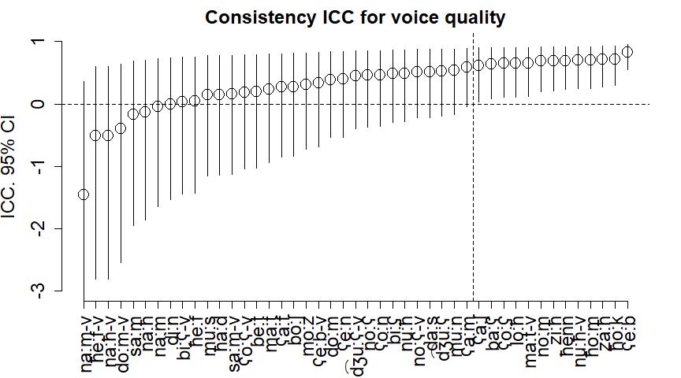

```r
abline(h = 0, lty=2)
abline(v = 32.5, lty=2)
```

##### 3.1.7.1.2 Agreement

We move to the agreement between raters

###### 3.1.7.1.2.1 Reordering and changing names

```r
## Agreement Voice Quality
ord.reRatingAgreeVQ <- PhoneticaICCRatingWordVQAgree[order(PhoneticaICCRatingWordVQAgree$ICCVal),]
rownames(ord.reRatingAgreeVQ) <- NULL
ord.reRatingAgreeVQ$context <- factor(ord.reRatingAgreeVQ$context)
ord.reRatingAgreeVQ$context <- as.character(ord.reRatingAgreeVQ$context)
ord.reRatingAgreeVQ$context[ord.reRatingAgreeVQ$context == "7aad-w"] <- "\u0127a:d"
ord.reRatingAgreeVQ$context[ord.reRatingAgreeVQ$context == "7eef-w"] <- "\u0127e:f"
ord.reRatingAgreeVQ$context[ord.reRatingAgreeVQ$context == "7eef-v"] <- "\u0127e:f-v"
ord.reRatingAgreeVQ$context[ord.reRatingAgreeVQ$context == "7en-w"] <- "\u0127enn"
ord.reRatingAgreeVQ$context[ord.reRatingAgreeVQ$context == "7ook-w"] <- "\u0127o:k"
ord.reRatingAgreeVQ$context[ord.reRatingAgreeVQ$context == "7oom-w"] <- "\u0127o:m"
ord.reRatingAgreeVQ$context[ord.reRatingAgreeVQ$context == "loo7-w"] <- "lo:\u0127"
ord.reRatingAgreeVQ$context[ord.reRatingAgreeVQ$context == "naa7-w"] <- "na:\u0127"
ord.reRatingAgreeVQ$context[ord.reRatingAgreeVQ$context == "naa7-v"] <- "na:\u0127-v"
ord.reRatingAgreeVQ$context[ord.reRatingAgreeVQ$context == "nuu7-w"] <- "nu:\u0127"
ord.reRatingAgreeVQ$context[ord.reRatingAgreeVQ$context == "nuu7-v"] <- "nu:\u0127-v"
ord.reRatingAgreeVQ$context[ord.reRatingAgreeVQ$context == "zaa7-w"] <- "za:\u0127"
ord.reRatingAgreeVQ$context[ord.reRatingAgreeVQ$context == "zii7-w"] <- "zi:\u0127"
ord.reRatingAgreeVQ$context[ord.reRatingAgreeVQ$context == "3aaf-w"] <- "ʕa:f"
ord.reRatingAgreeVQ$context[ord.reRatingAgreeVQ$context == "3aam-w"] <- "ʕa:m"
ord.reRatingAgreeVQ$context[ord.reRatingAgreeVQ$context == "3eeb-w"] <- "ʕe:b"
ord.reRatingAgreeVQ$context[ord.reRatingAgreeVQ$context == "3eeb-v"] <- "ʕe:b-v"
ord.reRatingAgreeVQ$context[ord.reRatingAgreeVQ$context == "3een-w"] <- "ʕe:n"
ord.reRatingAgreeVQ$context[ord.reRatingAgreeVQ$context == "3iish-w"] <- "ʕa:ʃ"
ord.reRatingAgreeVQ$context[ord.reRatingAgreeVQ$context == "3oo3-w"] <- "ʕo:ʕ"
ord.reRatingAgreeVQ$context[ord.reRatingAgreeVQ$context == "3oo3-v"] <- "ʕo:ʕ-v"
ord.reRatingAgreeVQ$context[ord.reRatingAgreeVQ$context == "3oon-w"] <- "ʕo:n"
ord.reRatingAgreeVQ$context[ord.reRatingAgreeVQ$context == "baa3-w"] <- "ba:ʕ"
ord.reRatingAgreeVQ$context[ord.reRatingAgreeVQ$context == "bii3-w"] <- "bi:ʕ"
ord.reRatingAgreeVQ$context[ord.reRatingAgreeVQ$context == "bii3-v"] <- "bi:ʕ-v"
ord.reRatingAgreeVQ$context[ord.reRatingAgreeVQ$context == "boosh-w"] <- "bo:ʃ"
ord.reRatingAgreeVQ$context[ord.reRatingAgreeVQ$context == "djuu3-w"] <- "d͡ʒu:ʕ"
ord.reRatingAgreeVQ$context[ord.reRatingAgreeVQ$context == "djuu3-v"] <- "d͡ʒu:ʕ-v"
ord.reRatingAgreeVQ$context[ord.reRatingAgreeVQ$context == "noo3-w"] <- "no:ʕ"
ord.reRatingAgreeVQ$context[ord.reRatingAgreeVQ$context == "noo3-v"] <- "no:ʕ-v"
ord.reRatingAgreeVQ$context[ord.reRatingAgreeVQ$context == "beet-w"] <- "be:t"
ord.reRatingAgreeVQ$context[ord.reRatingAgreeVQ$context == "daas-w"] <- "da:s"
ord.reRatingAgreeVQ$context[ord.reRatingAgreeVQ$context == "diin-w"] <- "di:n"
ord.reRatingAgreeVQ$context[ord.reRatingAgreeVQ$context == "doom-w"] <- "do:m"
ord.reRatingAgreeVQ$context[ord.reRatingAgreeVQ$context == "doom-v"] <- "do:m-v"
ord.reRatingAgreeVQ$context[ord.reRatingAgreeVQ$context == "beet-w"] <- "be:t"
ord.reRatingAgreeVQ$context[ord.reRatingAgreeVQ$context == "maat-w"] <- "ma:t"
ord.reRatingAgreeVQ$context[ord.reRatingAgreeVQ$context == "maat-v"] <- "ma:t-v"
ord.reRatingAgreeVQ$context[ord.reRatingAgreeVQ$context == "mooz-w"] <- "mo:z"
ord.reRatingAgreeVQ$context[ord.reRatingAgreeVQ$context == "muun-w"] <- "mu:n"
ord.reRatingAgreeVQ$context[ord.reRatingAgreeVQ$context == "muus-w"] <- "mu:s"
ord.reRatingAgreeVQ$context[ord.reRatingAgreeVQ$context == "naam-w"] <- "na:m"
ord.reRatingAgreeVQ$context[ord.reRatingAgreeVQ$context == "naam-v"] <- "na:m-v"
ord.reRatingAgreeVQ$context[ord.reRatingAgreeVQ$context == "noom-w"] <- "no:m"
ord.reRatingAgreeVQ$context[ord.reRatingAgreeVQ$context == "saam-w"] <- "sa:m"
ord.reRatingAgreeVQ$context[ord.reRatingAgreeVQ$context == "saam-v"] <- "sa:m-v"
ord.reRatingAgreeVQ$context[ord.reRatingAgreeVQ$context == "beet-w"] <- "be:t"
ord.reRatingAgreeVQ$context <- as.factor(ord.reRatingAgreeVQ$context)
ord.reRatingAgreeVQ$context <- as.vector(ord.reRatingAgreeVQ$context) #get rid of factors
ord.reRatingAgreeVQ$context = factor(ord.reRatingAgreeVQ$context,ord.reRatingAgreeVQ$context) #add ordered factors back
ord.reRatingAgreeVQ
```

| X | model | experiment | Type | level | context | context2 | ICCVal | lowerConfInt | upperConfInt | p.value |
| --- | --- | --- | --- | --- | --- | --- | --- | --- | --- | --- |
| 111 | VQICCRatingAgreeWordAvernaamv | Voice Quality | agreement | word | na:m-v | Isolation | -6.891892e-01 | -1.49363790 | 0.3128475 | 0.899991172 |
| 105 | VQICCRatingAgreeWordAver7eefv | Voice Quality | agreement | word | he:f-v | Isolation | -5.238095e-01 | -3.01024321 | 0.6111771 | 0.720370954 |
| 108 | VQICCRatingAgreeWordAverdoomv | Voice Quality | agreement | word | do:m-v | Isolation | -4.368932e-01 | -3.14861575 | 0.6480150 | 0.677625122 |
| 110 | VQICCRatingAgreeWordAvernaa7v | Voice Quality | agreement | word | na:h-v | Isolation | -2.946429e-01 | -1.35487511 | 0.5678582 | 0.712548787 |
| 132 | VQICCRatingAgreeWordAversaamw | Voice Quality | agreement | word | sa:m | o-n | -1.145038e-01 | -2.55862393 | 0.8088173 | 0.702169652 |
| 116 | VQICCRatingAgreeWordAvernaa7w | Voice Quality | agreement | word | na:h | n-7 | -6.060606e-02 | -0.90686642 | 0.6804175 | 0.632800084 |
| 119 | VQICCRatingAgreeWordAvernaamw | Voice Quality | agreement | word | na:m | n-n | -2.702703e-02 | -0.59218649 | 0.6097352 | 0.494282005 |
| 130 | VQICCRatingAgreeWordAverdiinw | Voice Quality | agreement | word | di:n | o-n | -2.040000e-16 | -0.34082818 | 0.5442112 | 0.451157515 |
| 106 | VQICCRatingAgreeWordAverbii3v | Voice Quality | agreement | word | bi:-v | Isolation | 2.290076e-02 | -0.72897358 | 0.6795363 | 0.426721186 |
| 101 | VQICCRatingAgreeWordAver7eefw | Voice Quality | agreement | word | he:f | 7-o | 3.225807e-02 | -0.90449089 | 0.7082651 | 0.421035498 |

[output cut: 35 more lines]

###### 3.1.7.1.2.2 Drawing the IRR figure

```r
plot(1:45, ord.reRatingAgreeVQ$ICCVal, axes=FALSE, ylim=c(-1,1),
     ylab="ICC. 95% CI", xlab="",cex=2,cex.lab=1.5,cex.main=1.5,
     main="Agreement ICC for voice quality",cex.axis=1.5)
axis(2,cex.lab=2,cex.axis=1.5)
```

```r
axis(1,at=1:45, labels = levels(ord.reRatingAgreeVQ$context),
     las=2,cex.lab=1.5,cex.axis=1.5)
for(i in 1:45) segments(i,ord.reRatingAgreeVQ$lowerConfInt[i],
                        i,ord.reRatingAgreeVQ$upperConfInt[i])
```

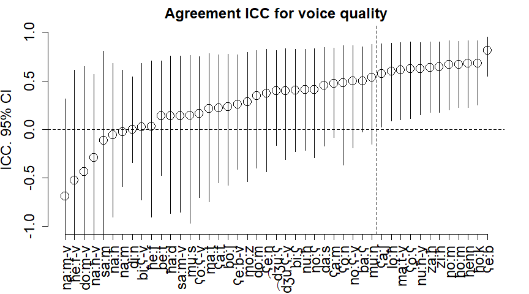

```r
abline(h = 0, lty=2)
abline(v = 33.5, lty=2)
```

As with the consistency above, the raters agreed among themselves on the majority of words as these received positive ICCs. The last 12 again received an agreement in ratings that was statistically significant. Some words containing pharyngeals, and specifically the voiced pharyngeal, receive positive ratings.

#### 3.1.7.2 Nasalisation

We move to the second experiment on Nasalisation. Overall, this experiment was slightly easier for the raters as evidenced by the consistency and agreement in their ICC scores.

##### 3.1.7.2.1 Consistency

We start with the consistency

###### 3.1.7.2.1.1 Reordering and changing names

```r
## Consistency nasalisation
ord.reRatingConsNas <- PhoneticaICCRatingWordNasCons[order(PhoneticaICCRatingWordNasCons$ICCVal),]
rownames(ord.reRatingConsNas) <- NULL
ord.reRatingConsNas$context <- factor(ord.reRatingConsNas$context)
ord.reRatingConsNas$context <- as.character(ord.reRatingConsNas$context)
ord.reRatingConsNas$context[ord.reRatingConsNas$context == "7aad-w"] <- "\u0127a:d"
ord.reRatingConsNas$context[ord.reRatingConsNas$context == "7eef-w"] <- "\u0127e:f"
ord.reRatingConsNas$context[ord.reRatingConsNas$context == "7eef-v"] <- "\u0127e:f-v"
ord.reRatingConsNas$context[ord.reRatingConsNas$context == "7en-w"] <- "\u0127enn"
ord.reRatingConsNas$context[ord.reRatingConsNas$context == "7ook-w"] <- "\u0127o:k"
ord.reRatingConsNas$context[ord.reRatingConsNas$context == "7oom-w"] <- "\u0127o:m"
ord.reRatingConsNas$context[ord.reRatingConsNas$context == "loo7-w"] <- "lo:\u0127"
ord.reRatingConsNas$context[ord.reRatingConsNas$context == "naa7-w"] <- "na:\u0127"
ord.reRatingConsNas$context[ord.reRatingConsNas$context == "naa7-v"] <- "na:\u0127-v"
ord.reRatingConsNas$context[ord.reRatingConsNas$context == "nuu7-w"] <- "nu:\u0127"
ord.reRatingConsNas$context[ord.reRatingConsNas$context == "nuu7-v"] <- "nu:\u0127-v"
ord.reRatingConsNas$context[ord.reRatingConsNas$context == "zaa7-w"] <- "za:\u0127"
ord.reRatingConsNas$context[ord.reRatingConsNas$context == "zii7-w"] <- "zi:\u0127"
ord.reRatingConsNas$context[ord.reRatingConsNas$context == "3aaf-w"] <- "ʕa:f"
ord.reRatingConsNas$context[ord.reRatingConsNas$context == "3aam-w"] <- "ʕa:m"
ord.reRatingConsNas$context[ord.reRatingConsNas$context == "3eeb-w"] <- "ʕe:b"
ord.reRatingConsNas$context[ord.reRatingConsNas$context == "3eeb-v"] <- "ʕe:b-v"
ord.reRatingConsNas$context[ord.reRatingConsNas$context == "3een-w"] <- "ʕe:n"
ord.reRatingConsNas$context[ord.reRatingConsNas$context == "3iish-w"] <- "ʕa:ʃ"
ord.reRatingConsNas$context[ord.reRatingConsNas$context == "3oo3-w"] <- "ʕo:ʕ"
ord.reRatingConsNas$context[ord.reRatingConsNas$context == "3oo3-v"] <- "ʕo:ʕ-v"
ord.reRatingConsNas$context[ord.reRatingConsNas$context == "3oon-w"] <- "ʕo:n"
ord.reRatingConsNas$context[ord.reRatingConsNas$context == "baa3-w"] <- "ba:ʕ"
ord.reRatingConsNas$context[ord.reRatingConsNas$context == "bii3-w"] <- "bi:ʕ"
ord.reRatingConsNas$context[ord.reRatingConsNas$context == "bii3-v"] <- "bi:ʕ-v"
ord.reRatingConsNas$context[ord.reRatingConsNas$context == "boosh-w"] <- "bo:ʃ"
ord.reRatingConsNas$context[ord.reRatingConsNas$context == "djuu3-w"] <- "d͡ʒu:ʕ"
ord.reRatingConsNas$context[ord.reRatingConsNas$context == "djuu3-v"] <- "d͡ʒu:ʕ-v"
ord.reRatingConsNas$context[ord.reRatingConsNas$context == "noo3-w"] <- "no:ʕ"
ord.reRatingConsNas$context[ord.reRatingConsNas$context == "noo3-v"] <- "no:ʕ-v"
ord.reRatingConsNas$context[ord.reRatingConsNas$context == "beet-w"] <- "be:t"
ord.reRatingConsNas$context[ord.reRatingConsNas$context == "daas-w"] <- "da:s"
ord.reRatingConsNas$context[ord.reRatingConsNas$context == "diin-w"] <- "di:n"
ord.reRatingConsNas$context[ord.reRatingConsNas$context == "doom-w"] <- "do:m"
ord.reRatingConsNas$context[ord.reRatingConsNas$context == "doom-v"] <- "do:m-v"
ord.reRatingConsNas$context[ord.reRatingConsNas$context == "beet-w"] <- "be:t"
ord.reRatingConsNas$context[ord.reRatingConsNas$context == "maat-w"] <- "ma:t"
ord.reRatingConsNas$context[ord.reRatingConsNas$context == "maat-v"] <- "ma:t-v"
ord.reRatingConsNas$context[ord.reRatingConsNas$context == "mooz-w"] <- "mo:z"
ord.reRatingConsNas$context[ord.reRatingConsNas$context == "muun-w"] <- "mu:n"
ord.reRatingConsNas$context[ord.reRatingConsNas$context == "muus-w"] <- "mu:s"
ord.reRatingConsNas$context[ord.reRatingConsNas$context == "naam-w"] <- "na:m"
ord.reRatingConsNas$context[ord.reRatingConsNas$context == "naam-v"] <- "na:m-v"
ord.reRatingConsNas$context[ord.reRatingConsNas$context == "noom-w"] <- "no:m"
ord.reRatingConsNas$context[ord.reRatingConsNas$context == "saam-w"] <- "sa:m"
ord.reRatingConsNas$context[ord.reRatingConsNas$context == "saam-v"] <- "sa:m-v"
ord.reRatingConsNas$context[ord.reRatingConsNas$context == "beet-w"] <- "be:t"
ord.reRatingConsNas$context <- as.factor(ord.reRatingConsNas$context)
ord.reRatingConsNas$context <- as.vector(ord.reRatingConsNas$context) #get rid of factors
ord.reRatingConsNas$context = factor(ord.reRatingConsNas$context,ord.reRatingConsNas$context) #add ordered factors back
ord.reRatingConsNas
```

| X | model | experiment | Type | level | context | context2 | ICCVal | lowerConfInt | upperConfInt | p.value |
| --- | --- | --- | --- | --- | --- | --- | --- | --- | --- | --- |
| 59 | NasICCRatingConsWordAver3oo3v | Nasalisation | consistency | word | o:-v | Isolation | -0.21030928 | -2.060706899 | 0.6847972 | 0.5846084140 |
| 61 | NasICCRatingConsWordAverbii3v | Nasalisation | consistency | word | bi:-v | Isolation | -0.17142857 | -1.962382900 | 0.6949230 | 0.5624433890 |
| 52 | NasICCRatingConsWordAver3iishw | Nasalisation | consistency | word | a: | 3-o | 0.06976744 | -1.352431117 | 0.7577381 | 0.3997525180 |
| 80 | NasICCRatingConsWordAverbii3w | Nasalisation | consistency | word | bi: | o-3 | 0.11042945 | -1.249602457 | 0.7683277 | 0.3683809130 |
| 82 | NasICCRatingConsWordAverloo7w | Nasalisation | consistency | word | lo:h | o-7 | 0.20689655 | -1.005650323 | 0.7934508 | 0.2908941910 |
| 79 | NasICCRatingConsWordAverbaa3w | Nasalisation | consistency | word | ba: | o-3 | 0.21212121 | -0.992437871 | 0.7948115 | 0.2866180450 |
| 84 | NasICCRatingConsWordAverzii7w | Nasalisation | consistency | word | zi:h | o-7 | 0.28064516 | -0.819150160 | 0.8126573 | 0.2304488950 |
| 88 | NasICCRatingConsWordAverbeetw | Nasalisation | consistency | word | be:t | o-o | 0.28682927 | -0.803511398 | 0.8142678 | 0.2254076940 |
| 83 | NasICCRatingConsWordAverzaa7w | Nasalisation | consistency | word | za:h | o-7 | 0.34015748 | -0.668651632 | 0.8281562 | 0.1825801270 |
| 46 | NasICCRatingConsWordAver3oo3w | Nasalisation | consistency | word | o: | 3--3 | 0.36923077 | -0.595129254 | 0.8357278 | 0.1599905070 |

[output cut: 35 more lines]

###### 3.1.7.2.1.2 Drawing the IRR figure

```r
par(oma = c(0, 0, 0, 0))
plot(1:45, ord.reRatingConsNas$ICCVal, axes=FALSE, ylim=c(-1,1),
     ylab="ICC. 95% CI", xlab="",cex=2,cex.lab=1.5,cex.main=1.5,
     main="Consistency ICC for nasalisation",cex.axis=1.5)
axis(2,cex.lab=2,cex.axis=1.5)
```

```r
axis(1,at=1:45, labels = levels(ord.reRatingConsNas$context),
     las=2,cex.lab=1.5,cex.axis=1.5)
for(i in 1:45) segments(i,ord.reRatingConsNas$lowerConfInt[i],
                        i,ord.reRatingConsNas$upperConfInt[i])
```

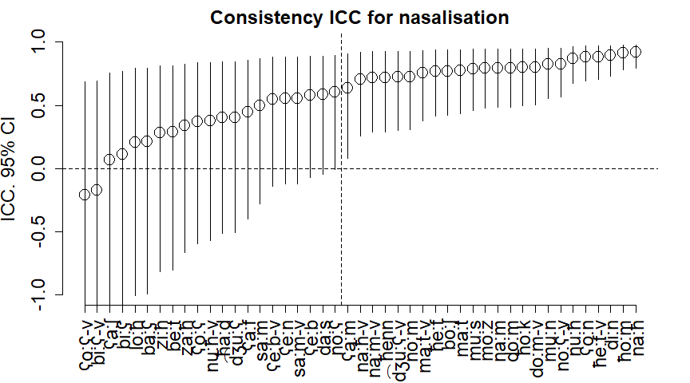

```r
abline(h = 0, lty=2)
abline(v = 21.5, lty=2)
```

The nasalisation experiment was somehow “easier” to raters as they were always consistent in their ratings with only two words received negative ICCs and nearly half of the words showing a statistically significant positive rating.

##### 3.1.7.2.2 Agreement

We move to the agreement

###### 3.1.7.2.2.1 Reordering and changing names

```r
## Agreement nasalisation
ord.reRatingAgreeNas <- PhoneticaICCRatingWordNasAgree[order(PhoneticaICCRatingWordNasAgree$ICCVal),]
rownames(ord.reRatingAgreeNas) <- NULL
ord.reRatingAgreeNas$context <- factor(ord.reRatingAgreeNas$context)
ord.reRatingAgreeNas$context <- as.character(ord.reRatingAgreeNas$context)
ord.reRatingAgreeNas$context[ord.reRatingAgreeNas$context == "7aad-w"] <- "\u0127a:d"
ord.reRatingAgreeNas$context[ord.reRatingAgreeNas$context == "7eef-w"] <- "\u0127e:f"
ord.reRatingAgreeNas$context[ord.reRatingAgreeNas$context == "7eef-v"] <- "\u0127e:f-v"
ord.reRatingAgreeNas$context[ord.reRatingAgreeNas$context == "7en-w"] <- "\u0127enn"
ord.reRatingAgreeNas$context[ord.reRatingAgreeNas$context == "7ook-w"] <- "\u0127o:k"
ord.reRatingAgreeNas$context[ord.reRatingAgreeNas$context == "7oom-w"] <- "\u0127o:m"
ord.reRatingAgreeNas$context[ord.reRatingAgreeNas$context == "loo7-w"] <- "lo:\u0127"
ord.reRatingAgreeNas$context[ord.reRatingAgreeNas$context == "naa7-w"] <- "na:\u0127"
ord.reRatingAgreeNas$context[ord.reRatingAgreeNas$context == "naa7-v"] <- "na:\u0127-v"
ord.reRatingAgreeNas$context[ord.reRatingAgreeNas$context == "nuu7-w"] <- "nu:\u0127"
ord.reRatingAgreeNas$context[ord.reRatingAgreeNas$context == "nuu7-v"] <- "nu:\u0127-v"
ord.reRatingAgreeNas$context[ord.reRatingAgreeNas$context == "zaa7-w"] <- "za:\u0127"
ord.reRatingAgreeNas$context[ord.reRatingAgreeNas$context == "zii7-w"] <- "zi:\u0127"
ord.reRatingAgreeNas$context[ord.reRatingAgreeNas$context == "3aaf-w"] <- "ʕa:f"
ord.reRatingAgreeNas$context[ord.reRatingAgreeNas$context == "3aam-w"] <- "ʕa:m"
ord.reRatingAgreeNas$context[ord.reRatingAgreeNas$context == "3eeb-w"] <- "ʕe:b"
ord.reRatingAgreeNas$context[ord.reRatingAgreeNas$context == "3eeb-v"] <- "ʕe:b-v"
ord.reRatingAgreeNas$context[ord.reRatingAgreeNas$context == "3een-w"] <- "ʕe:n"
ord.reRatingAgreeNas$context[ord.reRatingAgreeNas$context == "3iish-w"] <- "ʕa:ʃ"
ord.reRatingAgreeNas$context[ord.reRatingAgreeNas$context == "3oo3-w"] <- "ʕo:ʕ"
ord.reRatingAgreeNas$context[ord.reRatingAgreeNas$context == "3oo3-v"] <- "ʕo:ʕ-v"
ord.reRatingAgreeNas$context[ord.reRatingAgreeNas$context == "3oon-w"] <- "ʕo:n"
ord.reRatingAgreeNas$context[ord.reRatingAgreeNas$context == "baa3-w"] <- "ba:ʕ"
ord.reRatingAgreeNas$context[ord.reRatingAgreeNas$context == "bii3-w"] <- "bi:ʕ"
ord.reRatingAgreeNas$context[ord.reRatingAgreeNas$context == "bii3-v"] <- "bi:ʕ-v"
ord.reRatingAgreeNas$context[ord.reRatingAgreeNas$context == "boosh-w"] <- "bo:ʃ"
ord.reRatingAgreeNas$context[ord.reRatingAgreeNas$context == "djuu3-w"] <- "d͡ʒu:ʕ"
ord.reRatingAgreeNas$context[ord.reRatingAgreeNas$context == "djuu3-v"] <- "d͡ʒu:ʕ-v"
ord.reRatingAgreeNas$context[ord.reRatingAgreeNas$context == "noo3-w"] <- "no:ʕ"
ord.reRatingAgreeNas$context[ord.reRatingAgreeNas$context == "noo3-v"] <- "no:ʕ-v"
ord.reRatingAgreeNas$context[ord.reRatingAgreeNas$context == "beet-w"] <- "be:t"
ord.reRatingAgreeNas$context[ord.reRatingAgreeNas$context == "daas-w"] <- "da:s"
ord.reRatingAgreeNas$context[ord.reRatingAgreeNas$context == "diin-w"] <- "di:n"
ord.reRatingAgreeNas$context[ord.reRatingAgreeNas$context == "doom-w"] <- "do:m"
ord.reRatingAgreeNas$context[ord.reRatingAgreeNas$context == "doom-v"] <- "do:m-v"
ord.reRatingAgreeNas$context[ord.reRatingAgreeNas$context == "beet-w"] <- "be:t"
ord.reRatingAgreeNas$context[ord.reRatingAgreeNas$context == "maat-w"] <- "ma:t"
ord.reRatingAgreeNas$context[ord.reRatingAgreeNas$context == "maat-v"] <- "ma:t-v"
ord.reRatingAgreeNas$context[ord.reRatingAgreeNas$context == "mooz-w"] <- "mo:z"
ord.reRatingAgreeNas$context[ord.reRatingAgreeNas$context == "muun-w"] <- "mu:n"
ord.reRatingAgreeNas$context[ord.reRatingAgreeNas$context == "muus-w"] <- "mu:s"
ord.reRatingAgreeNas$context[ord.reRatingAgreeNas$context == "naam-w"] <- "na:m"
ord.reRatingAgreeNas$context[ord.reRatingAgreeNas$context == "naam-v"] <- "na:m-v"
ord.reRatingAgreeNas$context[ord.reRatingAgreeNas$context == "noom-w"] <- "no:m"
ord.reRatingAgreeNas$context[ord.reRatingAgreeNas$context == "saam-w"] <- "sa:m"
ord.reRatingAgreeNas$context[ord.reRatingAgreeNas$context == "saam-v"] <- "sa:m-v"
ord.reRatingAgreeNas$context[ord.reRatingAgreeNas$context == "beet-w"] <- "be:t"
ord.reRatingAgreeNas$context <- as.factor(ord.reRatingAgreeNas$context)
ord.reRatingAgreeNas$context <- as.vector(ord.reRatingAgreeNas$context) #get rid of factors
ord.reRatingAgreeNas$context = factor(ord.reRatingAgreeNas$context,ord.reRatingAgreeNas$context) #add ordered factors back
ord.reRatingAgreeNas
```

| X | model | experiment | Type | level | context | context2 | ICCVal | lowerConfInt | upperConfInt | p.value |
| --- | --- | --- | --- | --- | --- | --- | --- | --- | --- | --- |
| 14 | NasICCRatingAgreeWordAver3oo3v | Nasalisation | agreement | word | o:-v | Isolation | -0.11512415 | -1.463840399 | 0.8129300 | 0.9428257750 |
| 16 | NasICCRatingAgreeWordAverbii3v | Nasalisation | agreement | word | bi:-v | Isolation | -0.07400379 | -0.889816361 | 0.8138775 | 0.8141503730 |
| 7 | NasICCRatingAgreeWordAver3iishw | Nasalisation | agreement | word | a: | 3-o | 0.03448276 | -0.373158511 | 0.5973489 | 0.3983226930 |
| 35 | NasICCRatingAgreeWordAverbii3w | Nasalisation | agreement | word | bi: | o-3 | 0.05402161 | -0.346817254 | 0.6049686 | 0.3699400990 |
| 34 | NasICCRatingAgreeWordAverbaa3w | Nasalisation | agreement | word | ba: | o-3 | 0.11705686 | -0.348800905 | 0.6606865 | 0.2975527630 |
| 1 | NasICCRatingAgreeWordAver3oo3w | Nasalisation | agreement | word | o: | 3--3 | 0.14583333 | -0.177241327 | 0.6178280 | 0.2148735860 |
| 37 | NasICCRatingAgreeWordAverloo7w | Nasalisation | agreement | word | lo:h | o-7 | 0.15151515 | -0.526624679 | 0.7248706 | 0.2919213100 |
| 39 | NasICCRatingAgreeWordAverzii7w | Nasalisation | agreement | word | zi:h | o-7 | 0.17025440 | -0.345627612 | 0.7007255 | 0.2460413370 |
| 38 | NasICCRatingAgreeWordAverzaa7w | Nasalisation | agreement | word | za:h | o-7 | 0.18430034 | -0.265830943 | 0.6891975 | 0.2135840720 |
| 43 | NasICCRatingAgreeWordAverbeetw | Nasalisation | agreement | word | be:t | o-o | 0.22105263 | -0.470098924 | 0.7566503 | 0.2285600660 |

[output cut: 35 more lines]

###### 3.1.7.2.2.2 Drawing the IRR figure

```r
par(oma = c(0, 0, 0, 0))
plot(1:45, ord.reRatingAgreeNas$ICCVal, axes=FALSE, ylim=c(-1,1),
     ylab="ICC. 95% CI", xlab="",cex=2,cex.lab=1.5,cex.main=1.5,
     main="Agreement ICC for nasalisation",cex.axis=1.5)
axis(2,cex.lab=2,cex.axis=1.5)
```

```r
axis(1,at=1:45, labels = levels(ord.reRatingAgreeNas$context),
     las=2,cex.lab=1.5,cex.axis=1.5)
for(i in 1:45) segments(i,ord.reRatingAgreeNas$lowerConfInt[i],
                        i,ord.reRatingAgreeNas$upperConfInt[i])
```

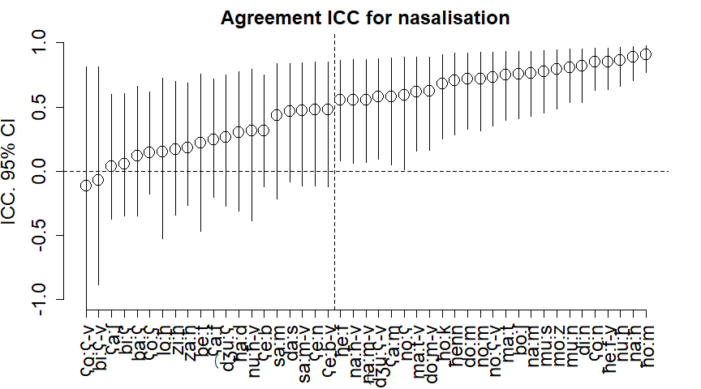

```r
abline(h = 0, lty=2)
abline(v = 20.5, lty=2)
```

### 3.1.8 Conclusion

Given the level of variance observed in the ICC scores for both consistency and agreements, it was necessary to use a statistical technique that takes into account this. It is possible that the raters were variables in some of their responses due to variable productions by the producing subjects and/or by the inherent differences between the raters.  
Below we report on the results of the Cumulative Logit Mixed Model with subjects, raters and items as random effects.

## 3.2 Cumulative Logit Mixed Models (clmm)

The data were analysed using Cumulative Link Mixed Models (CLMM) using the “ordinal” package.

Given the structure of the data, we used a random effects structure to account for the design. A crossed random effects structure (for the producing subjects, the raters and the items) was used. A by-rater random slope for Context was used as it improved the model fit compared to a model with it.

Our outcome is the response entered as a factor (3 for Voice Quality; 5 for Nasalisation). Our predictor was Context with the reference level being set to “Isolation”.

We compared various combinations, e.g., by subject and item random slopes; interactions with vowel, etc. and all these did not improve the model fit. Hence the models reported below are the optimal ones

### 3.2.1 Models

#### 3.2.1.1 Loading packages

Start by loading packages and install those that are not installed

```r
requiredPackages = c('ordinal')
for(p in requiredPackages){
  if(!require(p,character.only = TRUE)) install.packages(p)
  library(p,character.only = TRUE)
}
```

#### 3.2.1.2 Reading the data

We then read in the data and look at the structure to verify the class of each column.

```r
percVQDF <- read.csv("percVQDF.csv")
percNasDF <- read.csv("percNasDF.csv")
str(percVQDF)
```

```
'data.frame':   2430 obs. of  6 variables:
 $ X       : int  1 2 3 4 5 6 7 8 9 10 ...
 $ Response: int  3 2 3 3 3 2 3 3 3 3 ...
 $ Context : Factor w/ 14 levels "3--3","3-n","3-o",..: 7 6 11 6 8 6 1 6 12 11 ...
 $ Subject : Factor w/ 9 levels "p01","p02","p03",..: 4 4 4 4 4 4 4 4 4 4 ...
 $ Item    : Factor w/ 45 levels "3aaf-w","3aam-w",..: 38 37 24 23 41 40 8 7 27 19 ...
 $ Rater   : Factor w/ 6 levels "R01","R02","R03",..: 2 2 2 2 2 2 2 2 2 2 ...
```

```r
str(percNasDF)
```

```
'data.frame':   2430 obs. of  6 variables:
 $ X       : int  1 2 3 4 5 6 7 8 9 10 ...
 $ Response: int  4 4 4 3 3 4 2 3 2 4 ...
 $ Context : Factor w/ 14 levels "3--3","3-n","3-o",..: 7 6 11 6 8 6 1 6 12 11 ...
 $ Subject : Factor w/ 9 levels "p01","p02","p03",..: 4 4 4 4 4 4 4 4 4 4 ...
 $ Item    : Factor w/ 45 levels "3aaf-w","3aam-w",..: 38 37 24 23 41 40 8 7 27 19 ...
 $ Rater   : Factor w/ 6 levels "R01","R02","R03",..: 2 2 2 2 2 2 2 2 2 2 ...
```

#### 3.2.1.3 Changing a few things

We are changing a few things in both data-frames

1. Changing type of “response” to factor to suite the Cumulative Logit Mixed Model
2. Checking the levels of Context and changing the reference category to “Isolation”
3. Creating a new variable “ContextIPA” that contains the IPA symbols to be plotted in the figures below

```r
# factor level
percVQDF$Response <- as.factor(percVQDF$Response)
percNasDF$Response <- as.factor(percNasDF$Response)
# Changing the reference level
levels(percVQDF$Context)
```

```
 [1] "3--3"      "3-n"       "3-o"       "7-n"       "7-o"       "isolation"
 [7] "n-3"       "n-7"       "n-n"       "n-o"       "o-3"       "o-7"
[13] "o-n"       "o-o"
```

```r
percVQDF$Context <- relevel(percVQDF$Context, ref="isolation")
levels(percNasDF$Context)
```

```
 [1] "3--3"      "3-n"       "3-o"       "7-n"       "7-o"       "isolation"
 [7] "n-3"       "n-7"       "n-n"       "n-o"       "o-3"       "o-7"
[13] "o-n"       "o-o"
```

```r
percNasDF$Context <- relevel(percNasDF$Context, ref="isolation")
# Creating a new variable "ContextIPA"
## for Voice Quallity
percVQDF$ContextIPA <- percVQDF$Context
percVQDF$ContextIPA <- as.character(percVQDF$ContextIPA)
percVQDF$ContextIPA[percVQDF$ContextIPA == "7-o"] <- "\u0127-o"
percVQDF$ContextIPA[percVQDF$ContextIPA == "o-7"] <- "o-\u0127"
percVQDF$ContextIPA[percVQDF$ContextIPA == "7-n"] <- "\u0127-n"
percVQDF$ContextIPA[percVQDF$ContextIPA == "n-7"] <- "n-\u0127"
percVQDF$ContextIPA[percVQDF$ContextIPA == "3-o"] <- "ʕ-o"
percVQDF$ContextIPA[percVQDF$ContextIPA == "o-3"] <- "o-ʕ"
percVQDF$ContextIPA[percVQDF$ContextIPA == "3-n"] <- "ʕ-n"
percVQDF$ContextIPA[percVQDF$ContextIPA == "n-3"] <- "n-ʕ"
percVQDF$ContextIPA[percVQDF$ContextIPA == "3--3"] <- "ʕ-ʕ"
percVQDF$ContextIPA[percVQDF$ContextIPA == "isolation"] <- "Isolation"
percVQDF$ContextIPA <- as.factor(percVQDF$ContextIPA)
percVQDF$ContextIPA <- relevel(percVQDF$ContextIPA, ref="Isolation")
levels(percVQDF$ContextIPA)
```

```
 [1] "Isolation" "ʕ-ʕ"       "ʕ-n"       "ʕ-o"       "ħ-n"       "ħ-o"
 [7] "n-ʕ"       "n-ħ"       "n-n"       "n-o"       "o-ʕ"       "o-ħ"
[13] "o-n"       "o-o"
```

```r
# reordering levels of predictor
percVQDF$Context <- factor(percVQDF$Context, levels = c("isolation","7-n","7-o","n-7","n-n","n-o","n-3","o-7","o-n","o-o","o-3","3-n","3-o","3--3"))
percVQDF$ContextIPA <- factor(percVQDF$ContextIPA, levels = c("Isolation","\u0127-n","\u0127-o","n-\u0127","n-n","n-o","n-ʕ","o-\u0127","o-n","o-o","o-ʕ","ʕ-n","ʕ-o","ʕ-ʕ"))
levels(percVQDF$Context)
```

```
 [1] "isolation" "7-n"       "7-o"       "n-7"       "n-n"       "n-o"
 [7] "n-3"       "o-7"       "o-n"       "o-o"       "o-3"       "3-n"
[13] "3-o"       "3--3"
```

```r
levels(percVQDF$ContextIPA)
```

```
 [1] "Isolation" "ħ-n"       "ħ-o"       "n-ħ"       "n-n"       "n-o"
 [7] "n-ʕ"       "o-ħ"       "o-n"       "o-o"       "o-ʕ"       "ʕ-n"
[13] "ʕ-o"       "ʕ-ʕ"
```

```r
## for Nasalisation
percNasDF$ContextIPA <- percNasDF$Context
percNasDF$ContextIPA <- as.character(percNasDF$ContextIPA)
percNasDF$ContextIPA[percNasDF$ContextIPA == "7-o"] <- "\u0127-o"
percNasDF$ContextIPA[percNasDF$ContextIPA == "o-7"] <- "o-\u0127"
percNasDF$ContextIPA[percNasDF$ContextIPA == "7-n"] <- "\u0127-n"
percNasDF$ContextIPA[percNasDF$ContextIPA == "n-7"] <- "n-\u0127"
percNasDF$ContextIPA[percNasDF$ContextIPA == "3-o"] <- "ʕ-o"
percNasDF$ContextIPA[percNasDF$ContextIPA == "o-3"] <- "o-ʕ"
percNasDF$ContextIPA[percNasDF$ContextIPA == "3-n"] <- "ʕ-n"
percNasDF$ContextIPA[percNasDF$ContextIPA == "n-3"] <- "n-ʕ"
percNasDF$ContextIPA[percNasDF$ContextIPA == "3--3"] <- "ʕ-ʕ"
percNasDF$ContextIPA[percNasDF$ContextIPA == "isolation"] <- "Isolation"
percNasDF$ContextIPA <- as.factor(percNasDF$ContextIPA)
percNasDF$ContextIPA <- relevel(percNasDF$ContextIPA, ref="Isolation")
levels(percNasDF$ContextIPA)
```

```
 [1] "Isolation" "ʕ-ʕ"       "ʕ-n"       "ʕ-o"       "ħ-n"       "ħ-o"
 [7] "n-ʕ"       "n-ħ"       "n-n"       "n-o"       "o-ʕ"       "o-ħ"
[13] "o-n"       "o-o"
```

```r
# reordering levels of predictor
percNasDF$Context <- factor(percNasDF$Context, levels = c("isolation","7-n","7-o","n-7","n-n","n-o","n-3","o-7","o-n","o-o","o-3","3-n","3-o","3--3"))
percNasDF$ContextIPA <- factor(percNasDF$ContextIPA, levels = c("Isolation","\u0127-n","\u0127-o","n-\u0127","n-n","n-o","n-ʕ","o-\u0127","o-n","o-o","o-ʕ","ʕ-n","ʕ-o","ʕ-ʕ"))
levels(percNasDF$Context)
```

```
 [1] "isolation" "7-n"       "7-o"       "n-7"       "n-n"       "n-o"
 [7] "n-3"       "o-7"       "o-n"       "o-o"       "o-3"       "3-n"
[13] "3-o"       "3--3"
```

```r
levels(percNasDF$ContextIPA)
```

```
 [1] "Isolation" "ħ-n"       "ħ-o"       "n-ħ"       "n-n"       "n-o"
 [7] "n-ʕ"       "o-ħ"       "o-n"       "o-o"       "o-ʕ"       "ʕ-n"
[13] "ʕ-o"       "ʕ-ʕ"
```

### 3.2.2 Model specifications

#### 3.2.2.1 Voice Quality (VQ)

Below is our model specification for the full model that improved the model fit (we have tried various combinations, including by-Subject and by-Item random slopes for context; adding vowel as a fixed and random slope; consonant*vowel interactions, etc. However all these models either did not converge or did not improve the model fit compared to our model below)

##### 3.2.2.1.1 Full model

```r
system.time(fullCLMMVQSlope <- clmm(Response ~ Context + (1|Subject)+(1|Item)+(Context|Rater), data=percVQDF))
```

```
    user   system  elapsed
12092.34  1770.03  3481.42
```

##### 3.2.2.1.2 Null model

```r
system.time(fullCLMMVQNull <- clmm(Response ~ 1 + (1|Subject)+(1|Item)+(Context|Rater), data=percVQDF))
```

```
   user  system elapsed
2465.16    0.18 2467.66
```

#### 3.2.2.2 Nasalisation

Below is our model specification for the full model that improved the model fit (we have tried various combinations, including by-Subject and by-Item random slopes for context; adding vowel as a fixed and random slope; consonant*vowel interactions, etc. However all these models either did not converge or did not improve the model fit compared to our model below)

##### 3.2.2.2.1 Full model

```r
system.time(fullCLMMNasSlope <- clmm(Response ~ Context + (1|Subject)+(1|Item)+(Context|Rater), data=percNasDF))
```

```
    user   system  elapsed
14250.61  2189.17  4125.80
```

##### 3.2.2.2.2 Null model

```r
system.time(fullCLMMNasNull <- clmm(Response ~ 1 + (1|Subject)+(1|Item)+(Context|Rater), data=percNasDF))
```

```
   user  system elapsed
4406.65    1.21 4422.56
```

### 3.2.3 Results

The results below are divided into those on Voice Quality (VQ) followed by those on Nasalisation.

#### 3.2.3.1 Voice Quality (VQ)

##### 3.2.3.1.1 Model comparisons

```r
anova(fullCLMMVQNull,fullCLMMVQSlope)
```

```
Likelihood ratio tests of cumulative link models:
```

|  | formula: | link: | threshold: |
| --- | --- | --- | --- |
| fullCLMMVQNull | Response ~ 1 + (1 \| Subject) + (1 \| Item) + (Context \| Rater) | logit | flexible |
| fullCLMMVQSlope | Response ~ Context + (1 \| Subject) + (1 \| Item) + (Context \| Rater) | logit | flexible |

```
                no.par    AIC  logLik LR.stat df Pr(>Chisq)
fullCLMMVQNull     109 4019.0 -1900.5
fullCLMMVQSlope    122 4024.2 -1890.1  20.773 13    0.07754 .
---
Signif. codes:  0 ‘***’ 0.001 ‘**’ 0.01 ‘*’ 0.05 ‘.’ 0.1 ‘ ’ 1
```

##### 3.2.3.1.2 Summary

Next the summary presented below shows the results for each of the coefficients (minus the Intercept) and of the thresholds (1|2 and 2|3).

```r
summary(fullCLMMVQSlope)
```

```
Cumulative Link Mixed Model fitted with the Laplace approximation

formula: Response ~ Context + (1 | Subject) + (1 | Item) + (Context |      Rater)
data:    percVQDF
```

| link | threshold | nobs | logLik | AIC | niter | max.grad | cond.H |
| --- | --- | --- | --- | --- | --- | --- | --- |
| logit | flexible | 2430 | -1890.12 | 4024.23 | 57963(231856) | 6.13e-02 | 7.0e+02 |

```
Random effects:
 Groups  Name        Variance Std.Dev. Corr
 Item    (Intercept) 0.15224  0.3902
 Subject (Intercept) 0.21167  0.4601
 Rater   (Intercept) 0.87299  0.9343
         Context7-n  0.72657  0.8524   -0.501
         Context7-o  0.96219  0.9809   -0.471  0.960
         Contextn-7  0.83035  0.9112    0.004  0.642  0.748
         Contextn-n  0.08637  0.2939   -0.357  0.951  0.957  0.812
         Contextn-o  0.68494  0.8276   -0.677  0.772  0.597  0.137  0.644
         Contextn-3  0.56401  0.7510    0.549  0.302  0.342  0.750  0.435 -0.179
         Contexto-7  0.22833  0.4778   -0.433  0.686  0.775  0.870  0.771  0.318
         Contexto-n  0.14326  0.3785    0.219 -0.912 -0.811 -0.489 -0.842 -0.738
         Contexto-o  0.12513  0.3537   -0.760  0.230  0.373  0.170  0.178  0.092
         Contexto-3  0.78046  0.8834   -0.299  0.206  0.394  0.663  0.337 -0.169
         Context3-n  0.75679  0.8699   -0.657  0.821  0.910  0.705  0.815  0.477
         Context3-o  0.29034  0.5388   -0.528  0.765  0.906  0.687  0.789  0.337
         Context3--3 2.58037  1.6064   -0.148  0.842  0.933  0.849  0.918  0.342










  0.444
 -0.387 -0.389
 -0.344  0.558  0.154
  0.273  0.833  0.160  0.724
  0.188  0.894 -0.530  0.703  0.678
  0.173  0.777 -0.510  0.654  0.610  0.945
  0.550  0.709 -0.754  0.189  0.388  0.783  0.859
Number of groups:  Item 45,  Subject 9,  Rater 6

Coefficients:
             Estimate Std. Error z value Pr(>|z|)
Context7-n   0.991035   0.511102   1.939 0.052499 .
Context7-o   1.351805   0.511351   2.644 0.008203 **
Contextn-7   1.227045   0.533426   2.300 0.021431 *
Contextn-n   0.081502   0.334631   0.244 0.807573
Contextn-o  -0.161309   0.460430  -0.350 0.726080
Contextn-3   0.969618   0.605949   1.600 0.109562
Contexto-7   1.088271   0.369180   2.948 0.003200 **
Contexto-n   0.218397   0.346296   0.631 0.528259
Contexto-o  -0.005013   0.343046  -0.015 0.988340
Contexto-3   1.421408   0.479182   2.966 0.003014 **
Context3-n   1.679047   0.475315   3.532 0.000412 ***
Context3-o   2.536368   0.396778   6.392 1.63e-10 ***
Context3--3  3.001442   0.967364   3.103 0.001918 **
---
Signif. codes:  0 ‘***’ 0.001 ‘**’ 0.01 ‘*’ 0.05 ‘.’ 0.1 ‘ ’ 1

Threshold coefficients:
    Estimate Std. Error z value
1|2  -2.0512     0.4378  -4.685
2|3   1.6294     0.4365   3.732
```

##### 3.2.3.1.3 Figure

The summary of the results showed some statistically significant coefficients that displayed an association with increased ratings of “tense”. To allow us to visualise the ratings, we use the script below, which is a modified version of two scripts (see references in article).

The “beta” is the coefficient for each level of the fixed effect “Context” and “Theta” is the coefficient for each threshold of the ratings “Response”, 1|2, 2|3, etc…

```r
## below changes the margins
par(oma=c(1, 0, 0, 3),mgp=c(2, 1, 0))
xlimVQ = c(min(fullCLMMVQSlope$beta), max(fullCLMMVQSlope$beta))
ylimVQ = c(0,1)
plot(0,0,xlim=xlimVQ, ylim=ylimVQ, type="n", ylab=expression(Probability), xlab="", xaxt = "n",main="Predicted curves - Voice Quality",cex=2,cex.lab=1.5,cex.main=1.5,cex.axis=1.5)
axis(side = 1, at = c(0,fullCLMMVQSlope$beta),labels = levels(percVQDF$ContextIPA), las=2,cex=2,cex.lab=1.5,cex.axis=1.5)
```

```r
xsVQ = seq(xlimVQ[1], xlimVQ[2], length.out=100)
lines(xsVQ, plogis(fullCLMMVQSlope$Theta[1] - xsVQ), col='black')
lines(xsVQ, plogis(fullCLMMVQSlope$Theta[2] - xsVQ)-plogis(fullCLMMVQSlope$Theta[1] - xsVQ), col='red')
```

```r
lines(xsVQ, 1- (plogis(fullCLMMVQSlope$Theta[2] - xsVQ)), col='blue')
abline(v=c(0,fullCLMMVQSlope$beta),lty=3)
```

```r
abline(h=0, lty="dashed")
abline(h=1, lty="dashed")
```

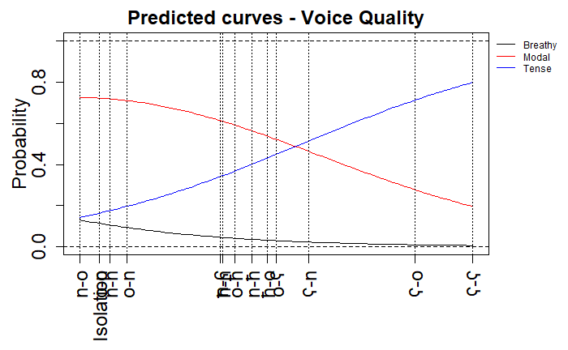

```r
legend(par('usr')[2], par('usr')[4], bty='n', xpd=NA,lty=1, col=c("black", "red", "blue"),
       legend=c("Breathy", "Modal", "Tense"),cex=0.75)
```

The figure above show that ratings of “Breathy” received less than 15% specifically and this was mainly either in the “Isolation” context or contexts with nasal consonants. This same group showed increase in ratings of “Modal” voice at a rate close to 75%. Ratings associated with the “Tense” voice increased steadily from this first group until reaching the pharyngeal contexts, with the highest ratings of “Tense” being present in /ʕ-ʕ/ context at a rate of 80%, with the remaining 20% being associated with “Modal” voice

#### 3.2.3.2 Nasalisation

##### 3.2.3.2.1 Model comparisons

With Nasalisation, model comparisons showed again an improvement of the model fit with our optimal model.

```r
anova(fullCLMMNasNull,fullCLMMNasSlope)
```

```
Likelihood ratio tests of cumulative link models:
```

|  | formula: | link: | threshold: |
| --- | --- | --- | --- |
| fullCLMMNasNull | Response ~ 1 + (1 \| Subject) + (1 \| Item) + (Context \| Rater) | logit | flexible |
| fullCLMMNasSlope | Response ~ Context + (1 \| Subject) + (1 \| Item) + (Context \| Rater) | logit | flexible |

```
                 no.par    AIC  logLik LR.stat df Pr(>Chisq)
fullCLMMNasNull     111 6016.0 -2897.0
fullCLMMNasSlope    124 6014.9 -2883.5  27.103 13    0.01204 *
---
Signif. codes:  0 ‘***’ 0.001 ‘**’ 0.01 ‘*’ 0.05 ‘.’ 0.1 ‘ ’ 1
```

##### 3.2.3.2.2 Summary

```r
summary(fullCLMMNasSlope)
```

```
Cumulative Link Mixed Model fitted with the Laplace approximation

formula: Response ~ Context + (1 | Subject) + (1 | Item) + (Context |      Rater)
data:    percNasDF
```

| link | threshold | nobs | logLik | AIC | niter | max.grad | cond.H |
| --- | --- | --- | --- | --- | --- | --- | --- |
| logit | flexible | 2430 | -2883.46 | 6014.92 | 56614(274083) | 8.48e-02 | 2.7e+03 |

```
Random effects:
 Groups  Name        Variance Std.Dev. Corr
 Item    (Intercept) 0.08327  0.2886
 Subject (Intercept) 0.08686  0.2947
 Rater   (Intercept) 2.06158  1.4358
         Context7-n  1.23832  1.1128   -0.977
         Context7-o  0.40683  0.6378    0.060  0.076
         Contextn-7  1.09881  1.0482   -0.959  0.907 -0.141
         Contextn-n  1.12499  1.0607   -0.947  0.944  0.015  0.966
         Contextn-o  1.89869  1.3779   -0.988  0.972  0.033  0.952  0.963
         Contextn-3  1.18456  1.0884   -0.936  0.921  0.146  0.951  0.972  0.970
         Contexto-7  0.13583  0.3685   -0.104  0.090  0.669  0.206  0.227  0.205
         Contexto-n  0.45232  0.6726   -0.856  0.857  0.270  0.841  0.902  0.926
         Contexto-o  0.22277  0.4720   -0.823  0.855  0.463  0.812  0.874  0.872
         Contexto-3  0.20164  0.4490    0.302 -0.322  0.564 -0.149 -0.153 -0.221
         Context3-n  0.48303  0.6950   -0.697  0.782  0.632  0.588  0.716  0.773
         Context3-o  0.91593  0.9570    0.517 -0.383  0.876 -0.544 -0.391 -0.429
         Context3--3 2.11385  1.4539    0.663 -0.562  0.692 -0.777 -0.682 -0.601










  0.406
  0.958  0.462
  0.938  0.583  0.915
  0.004  0.894  0.033  0.202
  0.793  0.480  0.877  0.900  0.071
 -0.293  0.529 -0.161  0.029  0.640  0.207
 -0.562  0.251 -0.386 -0.287  0.392  0.014  0.853
Number of groups:  Item 45,  Subject 9,  Rater 6

Coefficients:
            Estimate Std. Error z value Pr(>|z|)
Context7-n    2.9132     0.5458   5.337 9.43e-08 ***
Context7-o    0.2361     0.3665   0.644   0.5194
Contextn-7    3.0051     0.5272   5.700 1.20e-08 ***
Contextn-n    4.0126     0.5105   7.860 3.83e-15 ***
Contextn-o    4.0212     0.6239   6.446 1.15e-10 ***
Contextn-3    3.6125     0.6113   5.910 3.43e-09 ***
Contexto-7   -0.6175     0.3039  -2.032   0.0422 *
Contexto-n    3.1367     0.3768   8.324  < 2e-16 ***
Contexto-o   -0.2339     0.3204  -0.730   0.4653
Contexto-3   -0.1837     0.3203  -0.573   0.5663
Context3-n    3.5573     0.3917   9.081  < 2e-16 ***
Context3-o   -0.3729     0.4812  -0.775   0.4383
Context3--3  -1.6660     0.9537  -1.747   0.0807 .
---
Signif. codes:  0 ‘***’ 0.001 ‘**’ 0.01 ‘*’ 0.05 ‘.’ 0.1 ‘ ’ 1

Threshold coefficients:
    Estimate Std. Error z value
1|2  -0.6635     0.6068  -1.093
2|3   0.9297     0.6066   1.533
3|4   1.9334     0.6076   3.182
4|5   3.6733     0.6115   6.007
```

##### 3.2.3.2.3 Figure

```r
## below changes the margins
par(oma=c(1, 0, 0, 3),mgp=c(2, 1, 0))
xlimNas = c(min(fullCLMMNasSlope$beta), max(fullCLMMNasSlope$beta))
ylimNas = c(0,1)
plot(0,0,xlim=xlimNas, ylim=ylimNas, type="n", ylab=expression(Probability), xlab="", xaxt = "n",main="Predicted curves - Nasalisation",cex=2,cex.lab=1.5,cex.main=1.5,cex.axis=1.5)
axis(side = 1, at = c(0,fullCLMMNasSlope$beta),labels = levels(percNasDF$ContextIPA), las=2,cex=2,cex.lab=1.5,cex.axis=1.5)
```

```r
xsNas = seq(xlimNas[1], xlimNas[2], length.out=100)
lines(xsNas, plogis(fullCLMMNasSlope$Theta[1] - xsNas), col='black')
lines(xsNas, plogis(fullCLMMNasSlope$Theta[2] - xsNas)-plogis(fullCLMMNasSlope$Theta[1] - xsNas), col='red')
```

```r
lines(xsNas, plogis(fullCLMMNasSlope$Theta[3] - xsNas)-plogis(fullCLMMNasSlope$Theta[2] - xsNas), col='green')
lines(xsNas, plogis(fullCLMMNasSlope$Theta[4] - xsNas)-plogis(fullCLMMNasSlope$Theta[3] - xsNas), col='orange')
```

```r
lines(xsNas, 1-(plogis(fullCLMMNasSlope$Theta[4] - xsNas)), col='blue')
abline(v=c(0,fullCLMMNasSlope$beta),lty=3)
```

```r
abline(h=0, lty="dashed")
abline(h=1, lty="dashed")
```

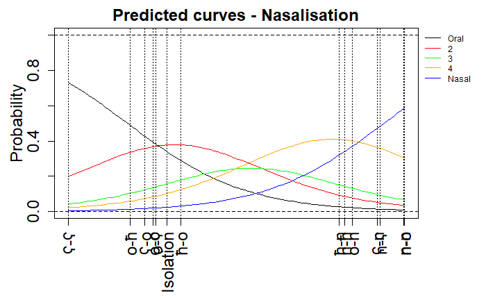

```r
legend(par('usr')[2], par('usr')[4], bty='n', xpd=NA,lty=1, col=c("black", "red", "green", "orange", "blue"),
       legend=c("Oral", "2", "3", "4", "Nasal"),cex=0.75)
```

The figure above shows how two groups are formed. The first group includes all oral contexts, Isolation and pharyngeals either on their own or with an oral context. The second group include all nasal contexts and those including pharyngeals and nasals. It is interesting to see that the percept of nasality is increased when a pharyngeal is associated with a nasal context; when associated with an oral context, the ratings are mostly “Oral”. The context “n-o” and “n-n” received the highest ratings of “Nasal” (4 and 5) with a sum of around 85-90%. This was followed by both “n-ʕ” and “ʕ-n” at a combined rating of around 80%.

### 3.2.4 Exploring random effects

This section is not part of the analsyes presented in the article, but are crucial at understanding how the rating experiment worked and how the random factors were crucial in generalising the results. Without including random effects, the model would have provided wrong predictions, given that our subjects, raters and words showed clear variance. This was taken into account in the models presented above.